# Final_Project_Data607

Ahmed Hassan, Crystal Quezada

2024-12-06

Libraries

# Abstract

## Housing Prices

First, the raw housing data is loaded directly from a CSV file hosted in a GitHub repository.

load USA dataset

```r
cpi_url <- "https://raw.githubusercontent.com/crystaliquezada/finalproject_data607/refs/heads/main/data/usa/cpi.csv"
electricity_url <- "https://raw.githubusercontent.com/crystaliquezada/finalproject_data607/refs/heads/main/data/usa/electricity_price_city_usa.csv"
m2_money_supply_url <- "https://raw.githubusercontent.com/crystaliquezada/finalproject_data607/refs/heads/main/data/usa/m2_money_supply.csv"
median_house_prices_sold_usa_url <- "https://raw.githubusercontent.com/crystaliquezada/finalproject_data607/refs/heads/main/data/usa/median_house_prices_sold_usa.csv"
employment_url <- "https://raw.githubusercontent.com/crystaliquezada/finalproject_data607/refs/heads/main/data/usa/total_non_farm_employment.csv"
median_household_income_usa_url <- "https://raw.githubusercontent.com/crystaliquezada/finalproject_data607/refs/heads/main/data/usa/median_household_income_usa.csv"

cpi_df <- read_csv(cpi_url)
electricity_df <- read_csv(electricity_url)
m2_money_supply_df <- read_csv(m2_money_supply_url)
median_house_prices_sold_usa_df <- read_csv(median_house_prices_sold_usa_url)
employment_df <- read_csv(employment_url)
median_household_income_usa_df <- read.csv(median_household_income_usa_url)
```

load nyc dataset

```r
nyc_median_income_url <- "https://raw.githubusercontent.com/crystaliquezada/finalproject_data607/refs/heads/main/data/new%20york%20tristate/nyc_median_household_income.csv"
nyc_tristate_electricity_url <- "https://raw.githubusercontent.com/crystaliquezada/finalproject_data607/refs/heads/main/data/new%20york%20tristate/nyc_tristate_electricity.csv"

nyc_median_income_df <- read_csv(nyc_median_income_url)
nyc_tristate_electricity_df <- read_csv(nyc_tristate_electricity_url)
```

load miami dataset

```r
miami_electricity_url <- "https://raw.githubusercontent.com/crystaliquezada/finalproject_data607/refs/heads/main/data/miami/miami_electricity.csv"
miami_median_income_url <- "https://raw.githubusercontent.com/crystaliquezada/finalproject_data607/refs/heads/main/data/miami/miami_median_household_income.csv"

miami_electricity_df <- read_csv(miami_electricity_url)
miami_median_income_df <- read_csv(miami_median_income_url)
```

load califonia dataset

```r
san_francisco_electricity_url  <- "https://raw.githubusercontent.com/crystaliquezada/finalproject_data607/refs/heads/main/data/california/san_francisco_electricity.csv"
san_francisco_median_income_url  <- "https://raw.githubusercontent.com/crystaliquezada/finalproject_data607/refs/heads/main/data/california/san_francisco_median_household_income.csv"
san_francisco_electricity_df <- read_csv(san_francisco_electricity_url )
san_francisco_median_income_df <- read_csv(san_francisco_median_income_url)
```

### Data Transformation

Electrcity Df Transformation

```r
transform_electricity_data <- function(df) {
  transformed_df <- df %>%
    pivot_longer(
      cols = -Year,
      names_to = "Month",
      values_to = "Electricity Cost per Kilowatt-Hour"
    ) %>%
    mutate(
      Date = as.Date(paste(Year, Month, "01", sep = "-"), format = "%Y-%b-%d")
    ) %>%
    select(Date, `Electricity Cost per Kilowatt-Hour`)

  return(transformed_df)
}

san_francisco_electricity_df <- transform_electricity_data(san_francisco_electricity_df)
electricity_df <- transform_electricity_data(electricity_df)
nyc_tristate_electricity_df <- transform_electricity_data(nyc_tristate_electricity_df)
miami_electricity_df<- transform_electricity_data(miami_electricity_df)
```

rename columns

```r
rename_column <- function(df, old_col_name, new_col_name) {
  renamed_df <- df %>%
    rename(!!new_col_name := !!sym(old_col_name))

  return(renamed_df)
}

san_francisco_median_income_df <- rename_column(san_francisco_median_income_df,"MHICA06075A052NCEN", "San Francisco Median Income")
nyc_median_income_df <- rename_column(nyc_median_income_df,"MEHOINUSNYA646N", "NYC Median Income")
miami_median_income_df <- rename_column(miami_median_income_df,"MEHOINUSFLA646N", "Miami Median Income")
median_household_income_usa_df <- rename_column(median_household_income_usa_df,"MEHOINUSA646N", "USA Median Income")

cpi_df <- rename_column(cpi_df,"CPIAUCSL", "CPI Index")
median_house_prices_sold_usa_df <- rename_column(median_house_prices_sold_usa_df,"MSPUS", "Median Housing Price Sold USA")
employment_df <- rename_column(employment_df,"PAYEMS", "Population Employed USA Thousand Per Person")

san_francisco_electricity_df <- rename_column(san_francisco_electricity_df,"Electricity Cost per Kilowatt-Hour", "San Francisco Electricity Cost per Kilowatt-Hour")
electricity_df <- rename_column(electricity_df,"Electricity Cost per Kilowatt-Hour", "USA Electricity Cost per Kilowatt-Hour")
nyc_tristate_electricity_df <- rename_column(nyc_tristate_electricity_df,"Electricity Cost per Kilowatt-Hour", "NYC Electricity Cost per Kilowatt-Hour")
miami_electricity_df<- rename_column(miami_electricity_df,"Electricity Cost per Kilowatt-Hour", "Miami Electricity Cost per Kilowatt-Hour")
```

Merge electricty data into a one df

```r
merged_electricity_df <- san_francisco_electricity_df %>%
  full_join(electricity_df, by = "Date") %>%
  full_join(nyc_tristate_electricity_df, by = "Date") %>%
  full_join(miami_electricity_df, by = "Date")

head(merged_electricity_df)
```

```
## # A tibble: 6 × 5
##   Date       San Francisco Electricity Cost per Kilowat…¹ USA Electricity Cost…²
##   <date>                                            <dbl>                  <dbl>
## 1 1990-01-01                                        0.109                  0.081
## 2 1990-02-01                                        0.109                  0.081
## 3 1990-03-01                                        0.109                  0.081
## 4 1990-04-01                                        0.109                  0.082
## 5 1990-05-01                                        0.111                  0.082
## 6 1990-06-01                                        0.111                  0.088
## # ℹ abbreviated names: ¹`San Francisco Electricity Cost per Kilowatt-Hour`,
## #   ²`USA Electricity Cost per Kilowatt-Hour`
## # ℹ 2 more variables: `NYC Electricity Cost per Kilowatt-Hour` <dbl>,
## #   `Miami Electricity Cost per Kilowatt-Hour` <dbl>
```

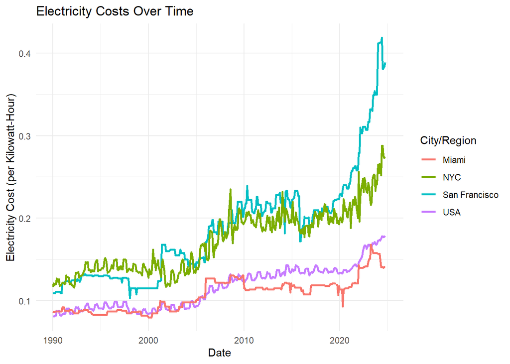

```r
ggplot(data = merged_electricity_df, aes(x = Date)) +
  geom_line(aes(y = `San Francisco Electricity Cost per Kilowatt-Hour`, color = "San Francisco"), size = 1) +
  geom_line(aes(y = `USA Electricity Cost per Kilowatt-Hour`, color = "USA"), size = 1) +
  geom_line(aes(y = `NYC Electricity Cost per Kilowatt-Hour`, color = "NYC"), size = 1) +
  geom_line(aes(y = `Miami Electricity Cost per Kilowatt-Hour`, color = "Miami"), size = 1) +
  labs(
    title = "Electricity Costs Over Time",
    x = "Date",
    y = "Electricity Cost (per Kilowatt-Hour)",
    color = "City/Region"
  ) +
  theme_minimal()
```

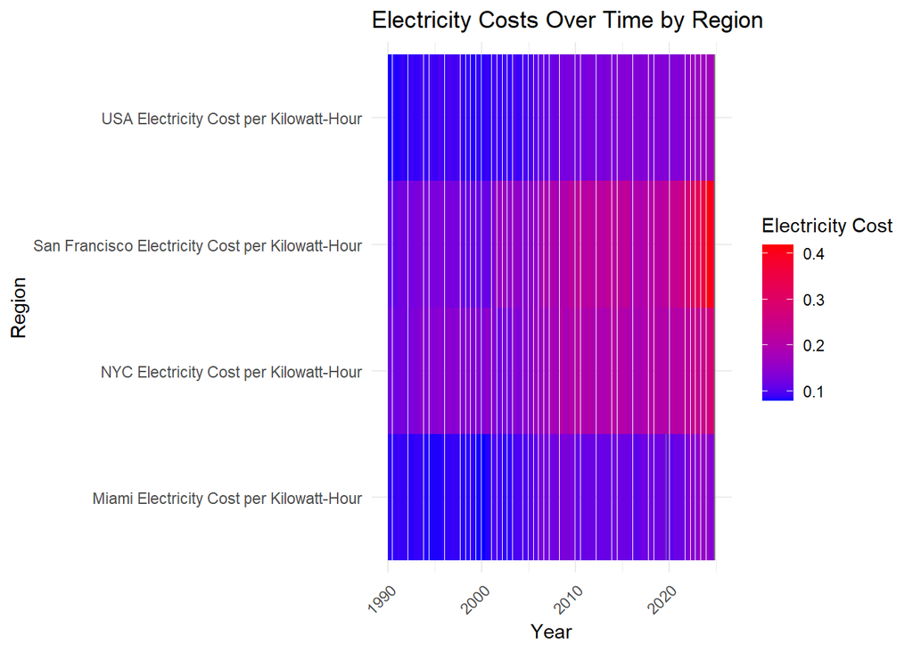

```r
heatmap_data <- merged_electricity_df %>%
  pivot_longer(
    cols = -Date,
    names_to = "Region",
    values_to = "Electricity_Cost"
  )

# Create the heatmap
ggplot(data = heatmap_data, aes(x = Date, y = Region, fill = Electricity_Cost)) +
  geom_tile() +
  scale_fill_gradient(low = "blue", high = "red", name = "Electricity Cost") +
  labs(
    title = "Electricity Costs Over Time by Region",
    x = "Year",
    y = "Region"
  ) +
  theme_minimal() +
  theme(axis.text.x = element_text(angle = 45, hjust = 1))
```

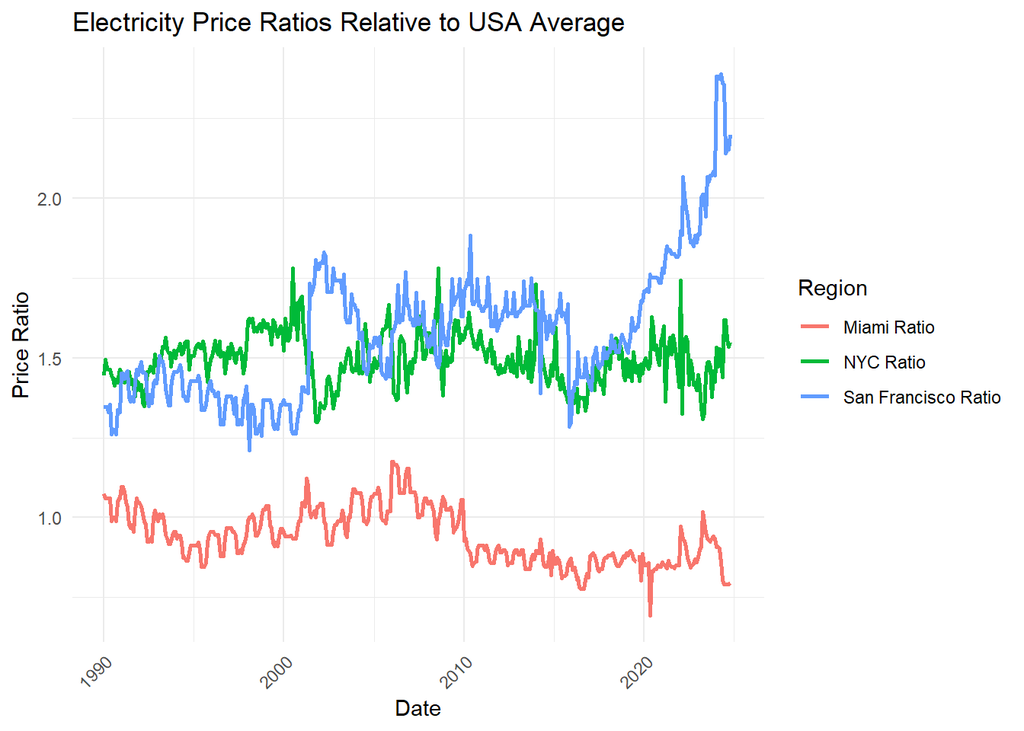

```r
ratio_df <- merged_electricity_df %>%
  mutate(
    `San Francisco Ratio` = `San Francisco Electricity Cost per Kilowatt-Hour` / `USA Electricity Cost per Kilowatt-Hour`,
    `NYC Ratio` = `NYC Electricity Cost per Kilowatt-Hour` / `USA Electricity Cost per Kilowatt-Hour`,
    `Miami Ratio` = `Miami Electricity Cost per Kilowatt-Hour` / `USA Electricity Cost per Kilowatt-Hour`
  ) %>%
  select(Date, `San Francisco Ratio`, `NYC Ratio`, `Miami Ratio`) %>%
  pivot_longer(
    cols = -Date,
    names_to = "Region",
    values_to = "Ratio"
  )

# Create the ratio plot
ggplot(data = ratio_df, aes(x = Date, y = Ratio, color = Region)) +
  geom_line(size = 1) +
  labs(
    title = "Electricity Price Ratios Relative to USA Average",
    x = "Date",
    y = "Price Ratio",
    color = "Region"
  ) +
  theme_minimal() +
  theme(axis.text.x = element_text(angle = 45, hjust = 1))
```

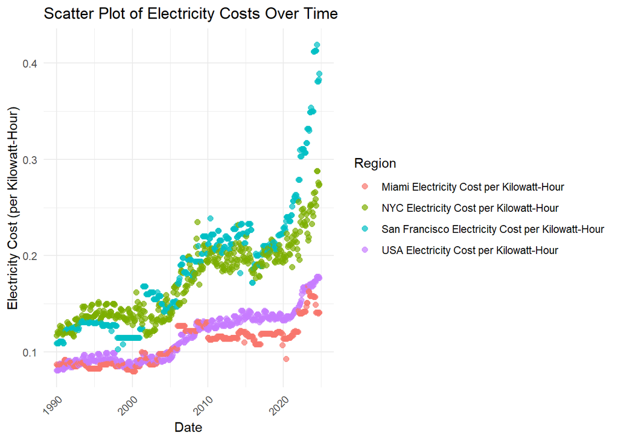

```r
scatter_data <- merged_electricity_df %>%
  pivot_longer(
    cols = -Date,
    names_to = "Region",
    values_to = "Electricity_Cost"
  )

ggplot(data = scatter_data, aes(x = Date, y = Electricity_Cost, color = Region)) +
  geom_point(size = 2, alpha = 0.7) +
  labs(
    title = "Scatter Plot of Electricity Costs Over Time",
    x = "Date",
    y = "Electricity Cost (per Kilowatt-Hour)",
    color = "Region"
  ) +
  theme_minimal() +
  theme(axis.text.x = element_text(angle = 45, hjust = 1))
```

```r
san_francisco_median_income_df <- san_francisco_median_income_df %>%
  mutate(DATE = as.Date(DATE))

nyc_median_income_df <- nyc_median_income_df %>%
  mutate(DATE = as.Date(DATE))

miami_median_income_df <- miami_median_income_df %>%
  mutate(DATE = as.Date(DATE))

median_household_income_usa_df <- median_household_income_usa_df %>%
  mutate(DATE = as.Date(DATE))

merged_income_df <- san_francisco_median_income_df %>%
  full_join(nyc_median_income_df, by = "DATE") %>%
  full_join(miami_median_income_df, by = "DATE") %>%
  full_join(median_household_income_usa_df, by = "DATE")

merged_income_df <- merged_income_df %>%
  select(-starts_with("Date.")) %>%
  slice(-1)

merged_income_df <- merged_income_df %>%
  mutate(across(
    c(`San Francisco Median Income`, `NYC Median Income`, `Miami Median Income`, `USA Median Income`),
    ~ as.numeric(.)
  ))
head(merged_income_df)
```

```
## # A tibble: 6 × 5
##   DATE       San Francisco Median In…¹ `NYC Median Income` `Miami Median Income`
##   <date>                         <dbl>               <dbl>                 <dbl>
## 1 1990-01-01                        NA               31590                 26690
## 2 1991-01-01                        NA               31790                 27250
## 3 1992-01-01                        NA               31050                 27350
## 4 1993-01-01                     34623               31700                 28550
## 5 1994-01-01                        NA               31900                 29290
## 6 1995-01-01                     37854               33030                 29750
## # ℹ abbreviated name: ¹`San Francisco Median Income`
## # ℹ 1 more variable: `USA Median Income` <dbl>
```

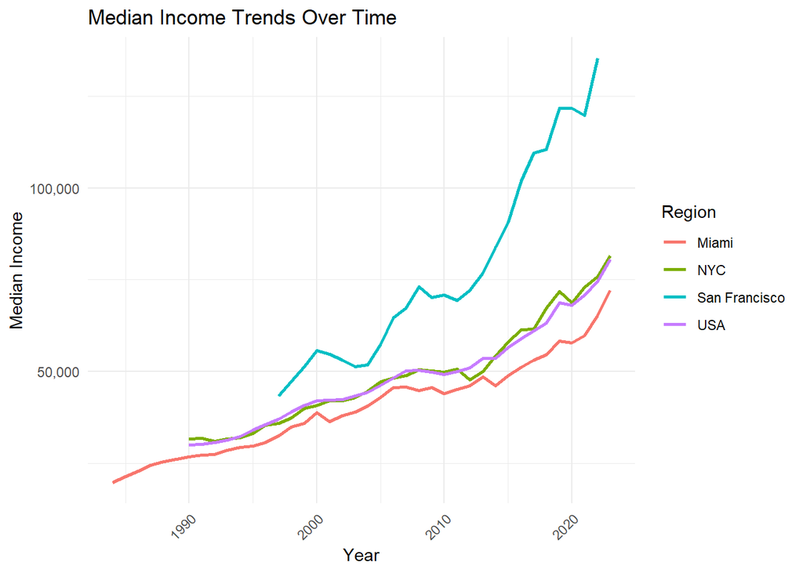

```r
ggplot(data = merged_income_df, aes(x = DATE)) +
  geom_line(aes(y = `San Francisco Median Income`, color = "San Francisco"), size = 1) +
  geom_line(aes(y = `NYC Median Income`, color = "NYC"), size = 1) +
  geom_line(aes(y = `Miami Median Income`, color = "Miami"), size = 1) +
  geom_line(aes(y = `USA Median Income`, color = "USA"), size = 1) +
  labs(
    title = "Median Income Trends Over Time",
    x = "Year",
    y = "Median Income",
    color = "Region"
  ) +
  theme_minimal() +
  theme(axis.text.x = element_text(angle = 45, hjust = 1))+
  scale_y_continuous(labels = scales::comma)
```

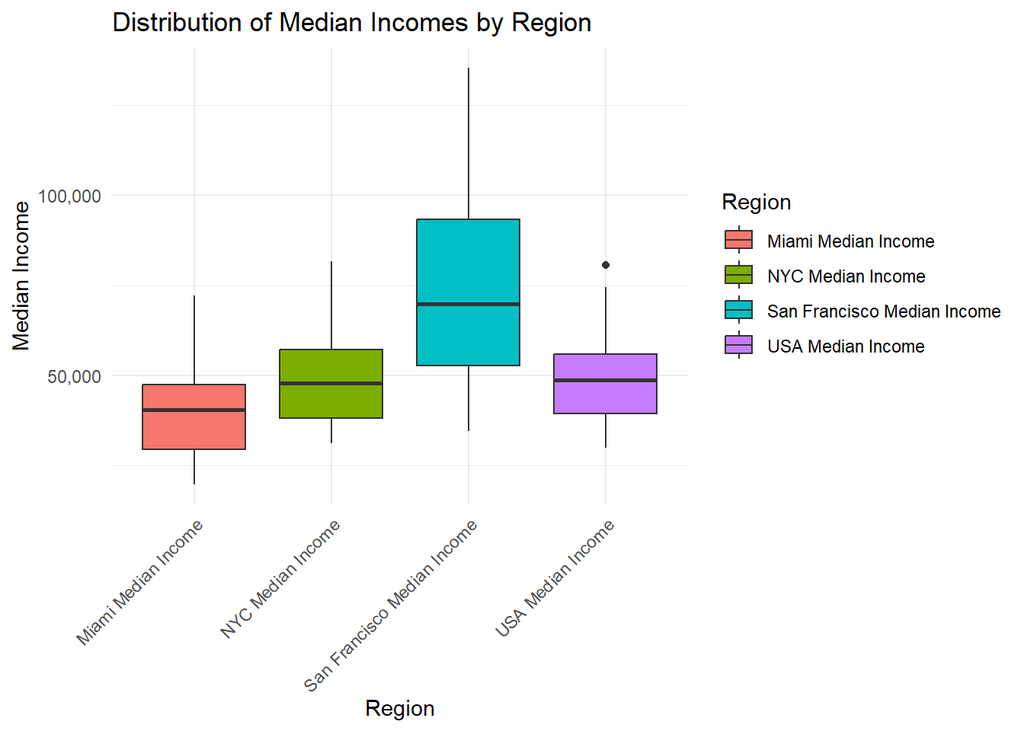

```r
long_income_df <- merged_income_df %>%
  pivot_longer(
    cols = -DATE,
    names_to = "Region",
    values_to = "Median_Income"
  )

ggplot(long_income_df, aes(x = Region, y = Median_Income, fill = Region)) +
  geom_boxplot() +
  labs(
    title = "Distribution of Median Incomes by Region",
    x = "Region",
    y = "Median Income"
  ) +
  theme_minimal() +
  theme(axis.text.x = element_text(angle = 45, hjust = 1))+
  scale_y_continuous(labels = scales::comma)
```

cpi

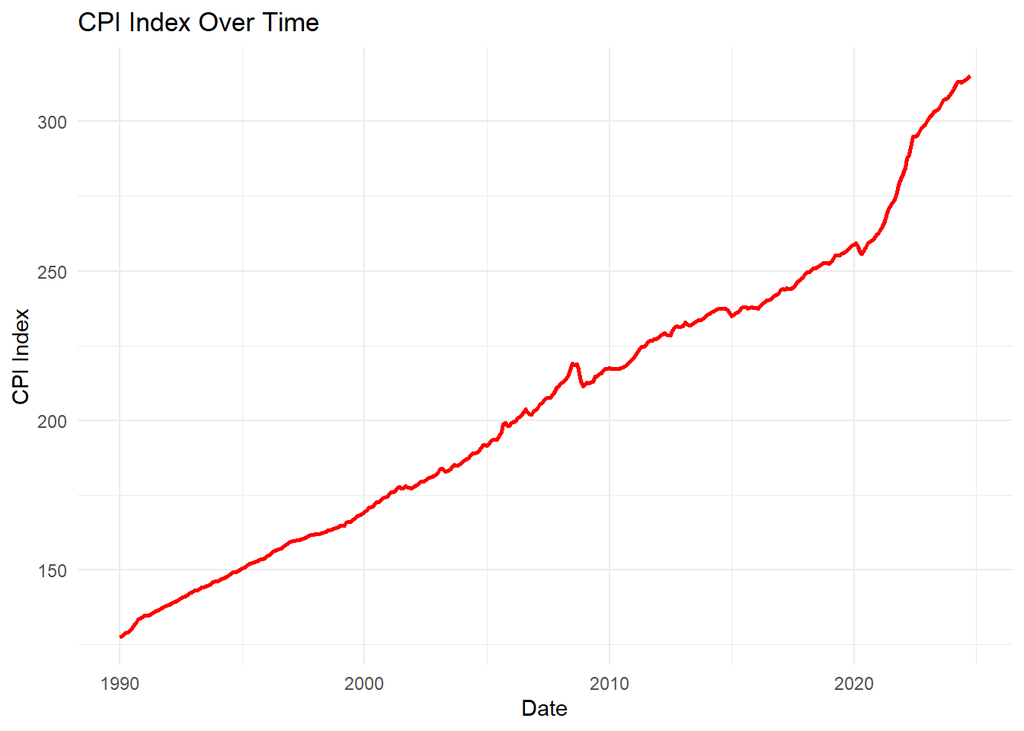

```r
ggplot(cpi_df, aes(x = as.Date(DATE), y = `CPI Index`)) +
  geom_line(color = "red", size = 1) +
  labs(
    title = "CPI Index Over Time",
    x = "Date",
    y = "CPI Index"
  ) +
  theme_minimal()
```

```r
colnames(cpi_df)
```

```
## [1] "DATE"      "CPI Index"
```

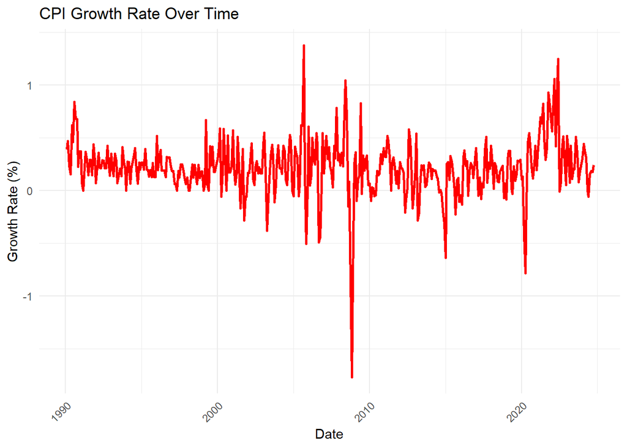

```r
# Calculate the growth rate for CPI
cpi_plot_df <- cpi_df %>%
  arrange(as.Date(DATE)) %>%
  mutate(Growth_Rate = (`CPI Index` - lag(`CPI Index`)) / lag(`CPI Index`) * 100) # Percentage growth

# Create the growth rate line plot
ggplot(cpi_plot_df, aes(x = as.Date(DATE), y = Growth_Rate)) +
  geom_line(color = "red", size = 1) +
  labs(
    title = "CPI Growth Rate Over Time",
    x = "Date",
    y = "Growth Rate (%)"
  ) +
  theme_minimal() +
  theme(axis.text.x = element_text(angle = 45, hjust = 1))
```

m2 money supply

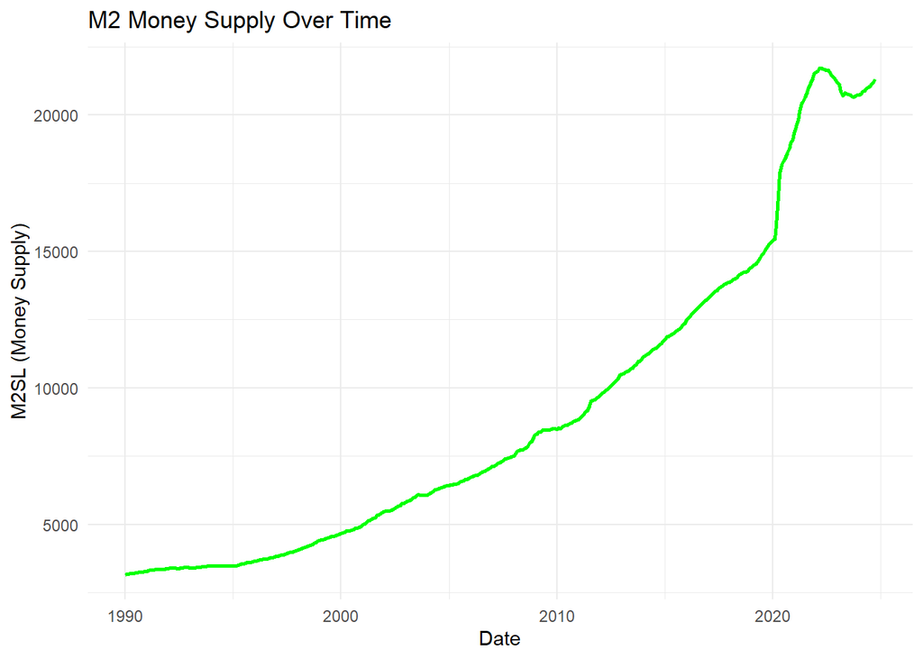

```r
ggplot(m2_money_supply_df, aes(x = as.Date(DATE), y = M2SL)) +
  geom_line(color = "green", size = 1) +
  labs(
    title = "M2 Money Supply Over Time",
    x = "Date",
    y = "M2SL (Money Supply)"
  ) +
  theme_minimal()
```

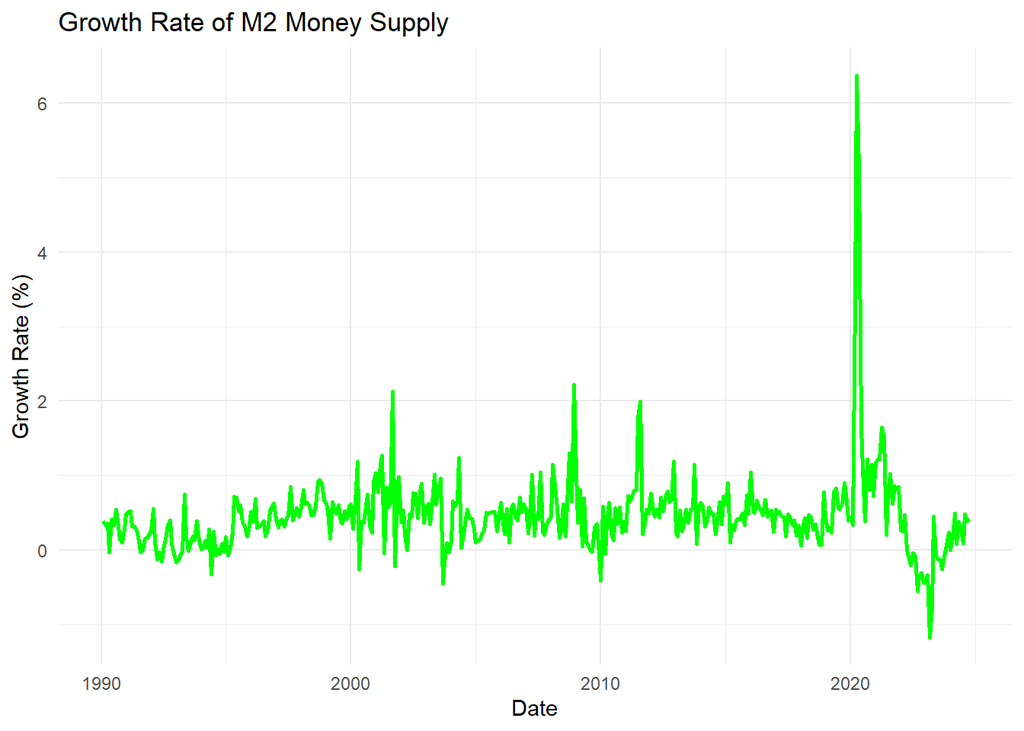

```r
m2_money_supply_plot_df <- m2_money_supply_df %>%
  mutate(Growth_Rate = (M2SL - lag(M2SL)) / lag(M2SL) * 100)
ggplot(m2_money_supply_plot_df, aes(x = as.Date(DATE), y = Growth_Rate)) +
  geom_line(color = "green", size = 1) +
  labs(title = "Growth Rate of M2 Money Supply", x = "Date", y = "Growth Rate (%)") +
  theme_minimal()
```

median house hold prices sold

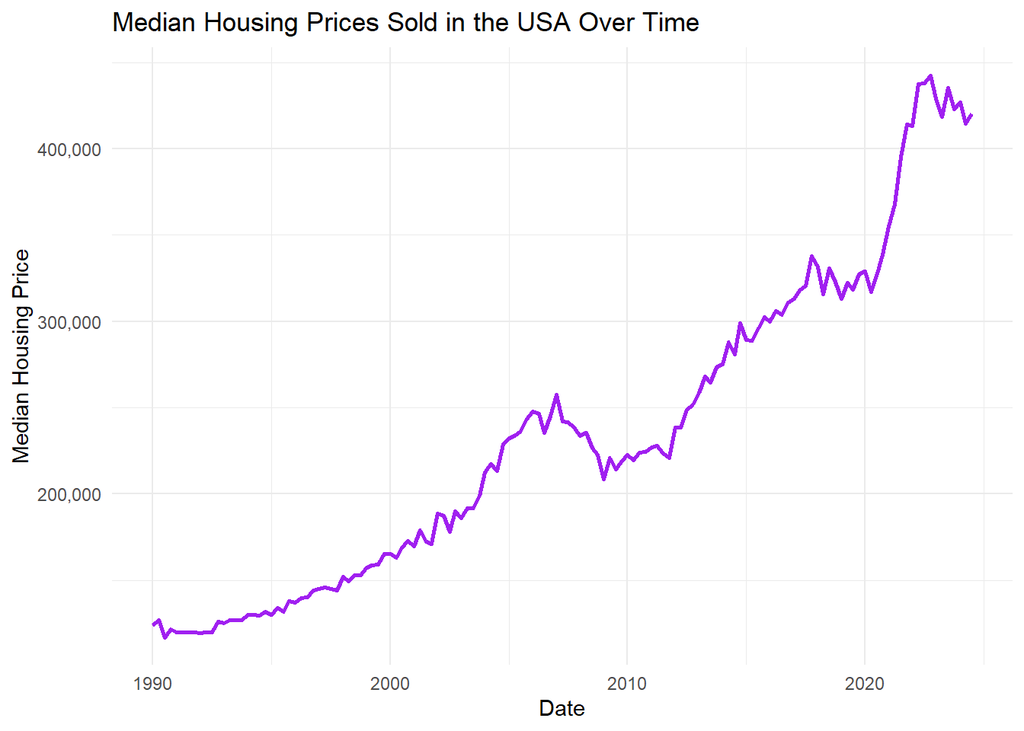

```r
ggplot(median_house_prices_sold_usa_df, aes(x = as.Date(DATE), y = `Median Housing Price Sold USA`)) +
  geom_line(color = "purple", size = 1) +
  labs(
    title = "Median Housing Prices Sold in the USA Over Time",
    x = "Date",
    y = "Median Housing Price"
  ) +
  theme_minimal()+
  scale_y_continuous(labels = scales::comma)
```

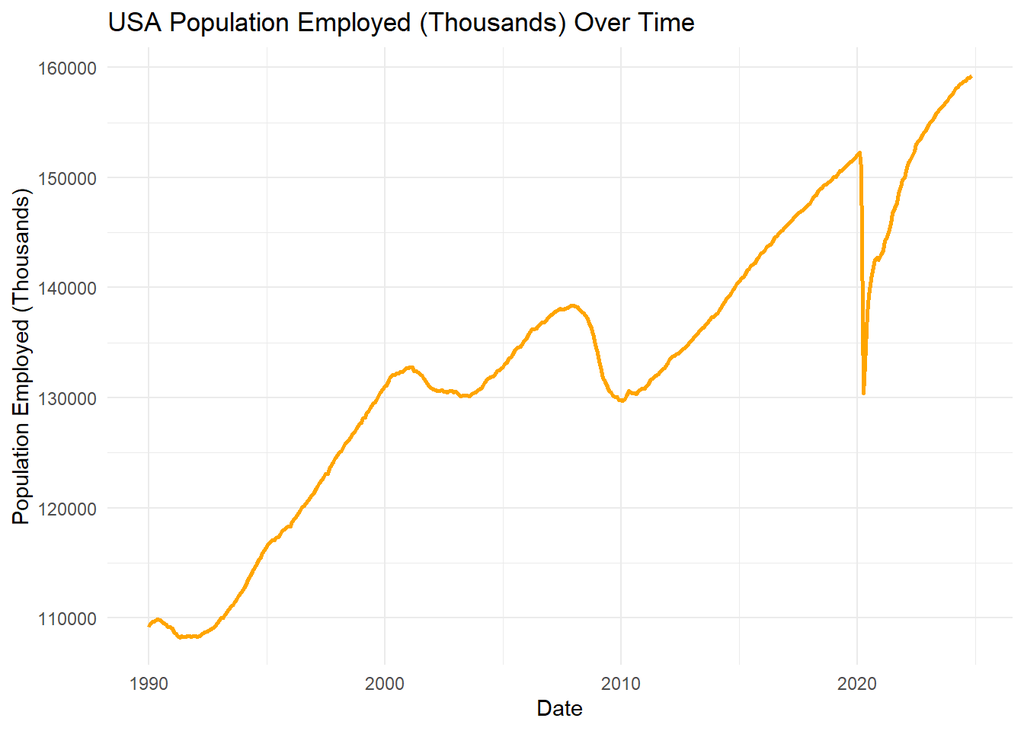

```r
ggplot(employment_df, aes(x = as.Date(DATE), y = `Population Employed USA Thousand Per Person`)) +
  geom_line(color = "orange", size = 1) +
  labs(
    title = "USA Population Employed (Thousands) Over Time",
    x = "Date",
    y = "Population Employed (Thousands)"
  ) +
  theme_minimal()
```

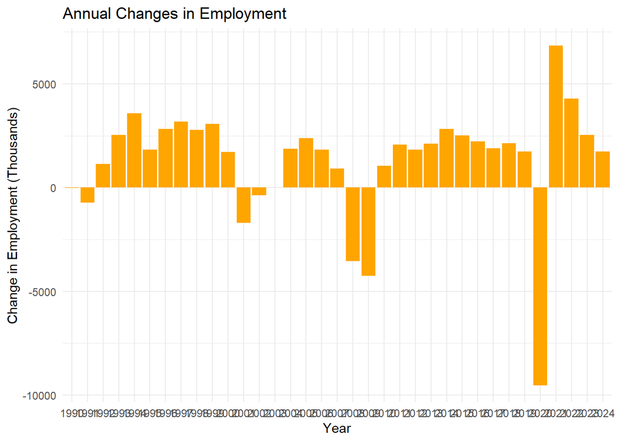

```r
employment_plot_df <- employment_df %>%
  mutate(Year = format(as.Date(DATE), "%Y")) %>%
  group_by(Year) %>%
  summarize(Annual_Change = last(`Population Employed USA Thousand Per Person`) -
                              first(`Population Employed USA Thousand Per Person`))
ggplot(employment_plot_df, aes(x = Year, y = Annual_Change)) +
  geom_bar(stat = "identity", fill = "orange") +
  labs(title = "Annual Changes in Employment", x = "Year", y = "Change in Employment (Thousands)") +
  theme_minimal()
```

### NYC Analysis on income

```r
merged_electricity_df <- merged_electricity_df %>% rename(DATE = Date)

nyc_data <- merged_income_df %>%
  select(DATE, `NYC Median Income`) %>%
  rename(Median_Income = `NYC Median Income`) %>%
  left_join(
    merged_electricity_df %>% select(DATE, `NYC Electricity Cost per Kilowatt-Hour`),
    by = "DATE"
  ) %>%
  left_join(
    cpi_df %>% rename(CPI_Index = `CPI Index`),
    by = "DATE"
  ) %>%
  left_join(
    m2_money_supply_df,
    by = "DATE"
  ) %>%
  left_join(
    employment_df %>% rename(Employment_Thousands = `Population Employed USA Thousand Per Person`),
    by = "DATE"
  )

nyc_data_clean <- nyc_data %>% na.omit()

regression_model <- lm(
  Median_Income ~ `NYC Electricity Cost per Kilowatt-Hour` + CPI_Index + M2SL + Employment_Thousands,
  data = nyc_data_clean
)

summary(regression_model)
```

```
##
## Call:
## lm(formula = Median_Income ~ `NYC Electricity Cost per Kilowatt-Hour` +
##     CPI_Index + M2SL + Employment_Thousands, data = nyc_data_clean)
##
## Residuals:
##     Min      1Q  Median      3Q     Max
## -3752.3  -937.2   117.2  1053.6  4971.3
##
## Coefficients:
##                                            Estimate Std. Error t value Pr(>|t|)
## (Intercept)                              -1.994e+04  7.030e+03  -2.836  0.00824
## `NYC Electricity Cost per Kilowatt-Hour` -1.245e+04  2.808e+04  -0.443  0.66078
## CPI_Index                                -3.917e+00  5.431e+01  -0.072  0.94300
## M2SL                                      1.821e+00  2.177e-01   8.367 3.20e-09
## Employment_Thousands                      4.267e-01  9.225e-02   4.626 7.17e-05
##
## (Intercept)                              **
## `NYC Electricity Cost per Kilowatt-Hour`
## CPI_Index
## M2SL                                     ***
## Employment_Thousands                     ***
## ---
## Signif. codes:  0 '***' 0.001 '**' 0.01 '*' 0.05 '.' 0.1 ' ' 1
##
## Residual standard error: 1853 on 29 degrees of freedom
## Multiple R-squared:  0.9849, Adjusted R-squared:  0.9828
## F-statistic: 473.5 on 4 and 29 DF,  p-value: < 2.2e-16
```

# Regression Analysis: NYC Median Income

## 1. Overall Model Fit

- **Multiple R-squared (0.9849)**:
  - This indicates that 98.49% of the variation in NYC Median Income is explained by the predictors (`NYC Electricity Cost per Kilowatt-Hour`, `CPI Index`, `M2 Money Supply`, and `Employment_Thousands`).
  - A very high R-squared suggests the model fits the data well.
- **Adjusted R-squared (0.9828)**:
  - This value adjusts for the number of predictors and confirms that the model explains a significant portion of the variation, even after accounting for the complexity of the model.
- **F-statistic (473.5, p < 2.2e-16)**:
  - The overall model is highly significant, indicating that at least one predictor has a meaningful relationship with NYC Median Income.

## 2. Coefficients

Each coefficient represents the estimated impact of a one-unit increase in the predictor on NYC Median Income, holding other variables constant:

- **Intercept (-19,940)**:
  - When all predictors are zero, the model predicts a baseline NYC Median Income of -$19,940.
  - This value is not interpretable in a practical sense because predictors like M2 Money Supply and employment can’t be zero.
- **NYC Electricity Cost per Kilowatt-Hour (-12,450)**:
  - **Estimate**: A $1 increase in NYC electricity cost is associated with a $12,450 decrease in NYC Median Income.
  - **p-value (0.661)**: Not statistically significant (p > 0.05), meaning there’s no strong evidence that electricity costs impact median income in NYC.
- **CPI Index (-3.92)**:
  - **Estimate**: A one-unit increase in the CPI Index is associated with a $3.92 decrease in NYC Median Income.
  - **p-value (0.943)**: Not statistically significant (p > 0.05). CPI does not have a measurable direct impact on NYC Median Income in this model.
- **M2 Money Supply (1.82)**:
  - **Estimate**: A $1 billion increase in M2 money supply is associated with a $1.82 increase in NYC Median Income.
  - **p-value (3.20e-09)**: Highly statistically significant (p < 0.001). There’s a strong positive correlation between M2 and NYC Median Income.
- **Employment Levels (0.427)**:
  - **Estimate**: An increase of 1,000 employed persons in the USA is associated with a $0.427 increase in NYC Median Income.
  - **p-value (7.17e-05)**: Highly statistically significant (p < 0.001). Employment levels are strongly correlated with NYC Median Income.

## 3. Residuals

Residuals represent the differences between observed and predicted values: - The residuals are relatively small, with a standard error of 1853, indicating that the model predicts NYC Median Income fairly accurately.

## 4. Key Takeaways

### Significant Predictors:

- `M2 Money Supply` and `Employment_Thousands` have statistically significant positive relationships with NYC Median Income.
  - This suggests that broader economic growth (as captured by M2 money supply) and higher employment levels significantly drive median income in NYC.

### Insignificant Predictors:

- `NYC Electricity Cost per Kilowatt-Hour` and `CPI Index` are not statistically significant, meaning there’s no strong evidence that these directly influence NYC Median Income in this model.

## 5. Correlation

- Yes, there is a strong correlation between NYC Median Income and both `M2 Money Supply` and `Employment_Thousands`, as evidenced by their significance levels and positive coefficients.
- However, no significant correlation is found with electricity costs or CPI Index.

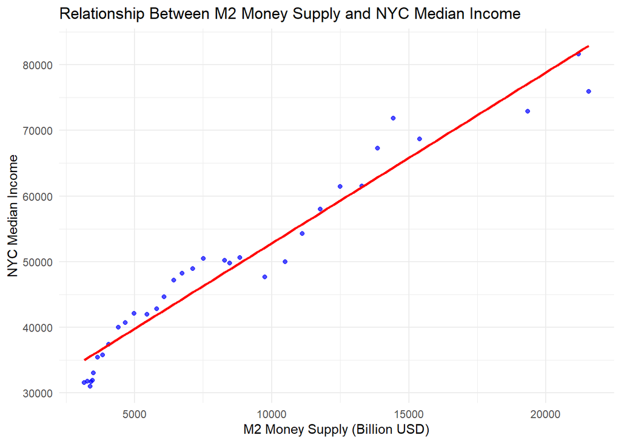

```r
ggplot(nyc_data_clean, aes(x = M2SL, y = Median_Income)) +
  geom_point(color = "blue", alpha = 0.7) +
  geom_smooth(method = "lm", color = "red", se = FALSE) +
  labs(
    title = "Relationship Between M2 Money Supply and NYC Median Income",
    x = "M2 Money Supply (Billion USD)",
    y = "NYC Median Income"
  ) +
  theme_minimal()
```

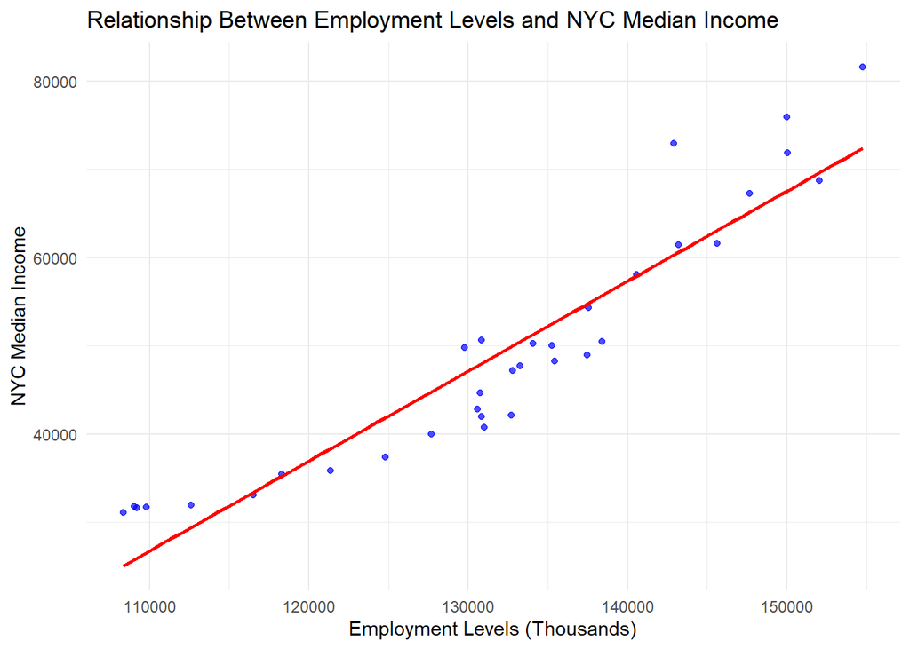

```r
ggplot(nyc_data_clean, aes(x = Employment_Thousands, y = Median_Income)) +
  geom_point(color = "blue", alpha = 0.7) +
  geom_smooth(method = "lm", color = "red", se = FALSE) +
  labs(
    title = "Relationship Between Employment Levels and NYC Median Income",
    x = "Employment Levels (Thousands)",
    y = "NYC Median Income"
  ) +
  theme_minimal()
```

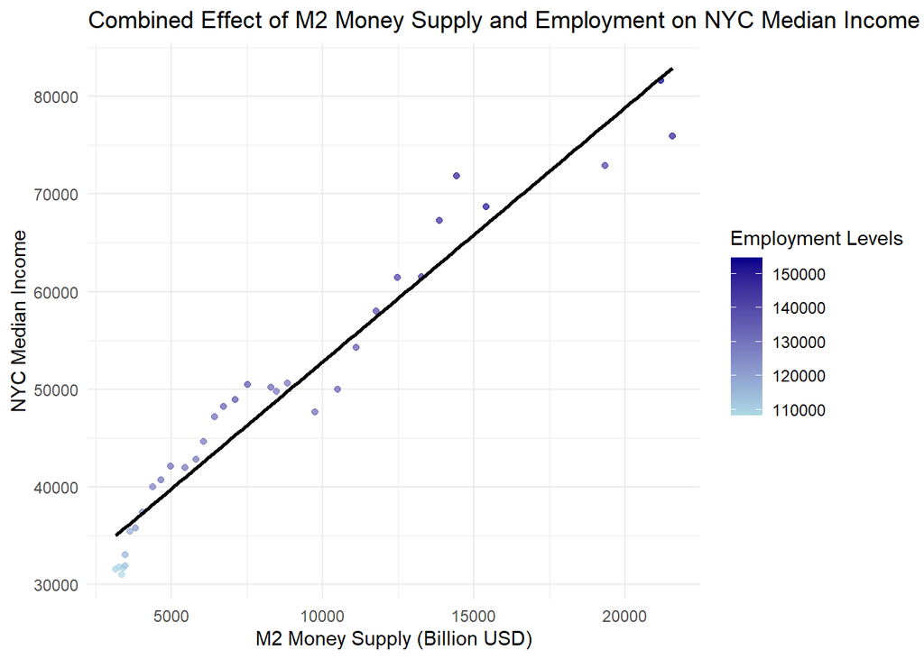

```r
ggplot(nyc_data_clean, aes(x = M2SL, y = Median_Income, color = Employment_Thousands)) +
  geom_point(alpha = 0.7) +
  geom_smooth(method = "lm", color = "black", se = FALSE) +
  scale_color_gradient(low = "lightblue", high = "darkblue", name = "Employment Levels") +
  labs(
    title = "Combined Effect of M2 Money Supply and Employment on NYC Median Income",
    x = "M2 Money Supply (Billion USD)",
    y = "NYC Median Income"
  ) +
  theme_minimal()
```

### MIAMI DATA ANALYSIS

```r
# Merge and clean the Miami-specific data
miami_data <- merged_income_df %>%
  select(DATE, `Miami Median Income`) %>%
  rename(Median_Income = `Miami Median Income`) %>%
  left_join(
    merged_electricity_df %>% select(DATE, `Miami Electricity Cost per Kilowatt-Hour`),
    by = "DATE"
  ) %>%
  left_join(
    cpi_df %>% rename(CPI_Index = `CPI Index`),
    by = "DATE"
  ) %>%
  left_join(
    m2_money_supply_df,
    by = "DATE"
  ) %>%
  left_join(
    employment_df %>% rename(Employment_Thousands = `Population Employed USA Thousand Per Person`),
    by = "DATE"
  )

miami_data_clean <- miami_data %>% na.omit()

regression_model_miami <- lm(
  Median_Income ~ `Miami Electricity Cost per Kilowatt-Hour` + CPI_Index + M2SL + Employment_Thousands,
  data = miami_data_clean
)

summary(regression_model_miami)
```

```
##
## Call:
## lm(formula = Median_Income ~ `Miami Electricity Cost per Kilowatt-Hour` +
##     CPI_Index + M2SL + Employment_Thousands, data = miami_data_clean)
##
## Residuals:
##     Min      1Q  Median      3Q     Max
## -3363.8  -813.3   -44.1   792.6  3708.2
##
## Coefficients:
##                                              Estimate Std. Error t value
## (Intercept)                                -2.383e+04  4.960e+03  -4.805
## `Miami Electricity Cost per Kilowatt-Hour`  7.909e+04  3.113e+04   2.541
## CPI_Index                                   2.385e+01  3.468e+01   0.688
## M2SL                                        9.229e-01  1.712e-01   5.391
## Employment_Thousands                        3.488e-01  6.120e-02   5.699
##                                            Pr(>|t|)
## (Intercept)                                4.36e-05 ***
## `Miami Electricity Cost per Kilowatt-Hour`   0.0167 *
## CPI_Index                                    0.4971
## M2SL                                       8.56e-06 ***
## Employment_Thousands                       3.65e-06 ***
## ---
## Signif. codes:  0 '***' 0.001 '**' 0.01 '*' 0.05 '.' 0.1 ' ' 1
##
## Residual standard error: 1437 on 29 degrees of freedom
## Multiple R-squared:  0.9862, Adjusted R-squared:  0.9842
## F-statistic: 516.3 on 4 and 29 DF,  p-value: < 2.2e-16
```

# Regression Analysis: Miami Median Income

## 1. Overall Model Fit

- **Multiple R-squared (0.9862)**:
  - The model explains 98.62% of the variation in Miami Median Income, indicating a very strong fit.
- **Adjusted R-squared (0.9842)**:
  - After accounting for the number of predictors, the model still explains a substantial portion of the variation in Miami Median Income.
- **F-statistic (516.3, p < 2.2e-16)**:
  - The overall model is highly significant, meaning at least one predictor has a strong relationship with Miami Median Income.

## 2. Coefficients

Each coefficient represents the estimated impact of a one-unit increase in the predictor on Miami Median Income, holding other variables constant:

- **Intercept (-23,830)**:
  - When all predictors are zero, the model predicts a baseline Miami Median Income of -$23,830.
  - This value is not meaningful since predictors like `M2 Money Supply` and `Employment_Thousands` cannot realistically be zero.
- **Miami Electricity Cost per Kilowatt-Hour (79,090)**:
  - **Estimate**: A $1 increase in electricity costs is associated with a $79,090 increase in Miami Median Income.
  - **p-value (0.0167)**: Statistically significant (p < 0.05), suggesting that electricity costs have a meaningful positive relationship with Miami Median Income.
- **CPI Index (23.85)**:
  - **Estimate**: A one-unit increase in the CPI Index is associated with a $23.85 increase in Miami Median Income.
  - **p-value (0.4971)**: Not statistically significant (p > 0.05), meaning CPI does not have a measurable impact on Miami Median Income in this model.
- **M2 Money Supply (0.9229)**:
  - **Estimate**: A $1 billion increase in M2 money supply is associated with a $0.9229 increase in Miami Median Income.
  - **p-value (8.56e-06)**: Highly statistically significant (p < 0.001). There is a strong positive relationship between M2 money supply and Miami Median Income.
- **Employment Levels (0.3488)**:
  - **Estimate**: An increase of 1,000 employed persons in the USA is associated with a $0.3488 increase in Miami Median Income.
  - **p-value (3.65e-06)**: Highly statistically significant (p < 0.001). Employment levels are strongly correlated with Miami Median Income.

## 3. Residuals

- **Residual Standard Error (1437)**:
  - Indicates the typical difference between observed and predicted values for Miami Median Income.
  - The residuals are smaller compared to the NYC model, suggesting more precise predictions for Miami.

## 4. Key Takeaways

### Significant Predictors:

- **Miami Electricity Costs**: Unlike NYC, electricity costs are significant for Miami and positively correlated with median income. This may reflect higher energy expenses in the region influencing income.
- **M2 Money Supply and Employment Levels**: These remain highly significant, as in NYC, indicating broader economic factors (monetary supply and job availability) are key drivers of income.

### Insignificant Predictors:

- **CPI Index**: Similar to NYC, CPI does not show a significant relationship with Miami Median Income in this model.

## 5. Comparison with NYC

- **Electricity Costs**: Significant for Miami but not for NYC, likely reflecting regional differences in cost structures and energy consumption.
- **CPI**: Insignificant in both cities.
- **M2 Money Supply and Employment Levels**: Consistently significant and positively correlated with median income in both cities.

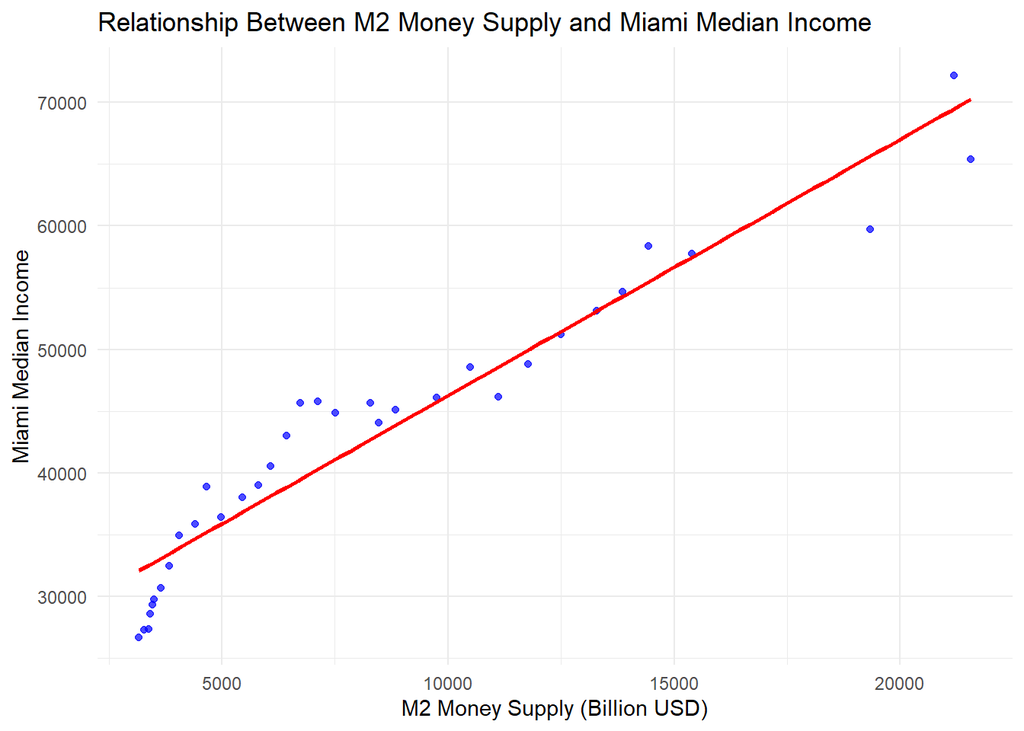

```r
ggplot(miami_data_clean, aes(x = M2SL, y = Median_Income)) +
  geom_point(color = "blue", alpha = 0.7) +
  geom_smooth(method = "lm", color = "red", se = FALSE) +
  labs(
    title = "Relationship Between M2 Money Supply and Miami Median Income",
    x = "M2 Money Supply (Billion USD)",
    y = "Miami Median Income"
  ) +
  theme_minimal()
```

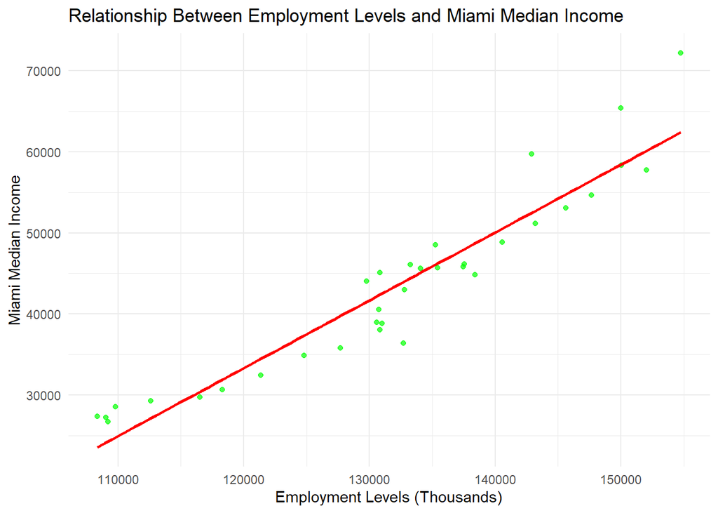

```r
ggplot(miami_data_clean, aes(x = Employment_Thousands, y = Median_Income)) +
  geom_point(color = "green", alpha = 0.7) +
  geom_smooth(method = "lm", color = "red", se = FALSE) +
  labs(
    title = "Relationship Between Employment Levels and Miami Median Income",
    x = "Employment Levels (Thousands)",
    y = "Miami Median Income"
  ) +
  theme_minimal()
```

### San Francisco DATA ANALYSIS

```r
# Merge and clean the San Francisco-specific data
sf_data <- merged_income_df %>%
  select(DATE, `San Francisco Median Income`) %>%
  rename(Median_Income = `San Francisco Median Income`) %>%
  left_join(
    merged_electricity_df %>% select(DATE, `San Francisco Electricity Cost per Kilowatt-Hour`),
    by = "DATE"
  ) %>%
  left_join(
    cpi_df %>% rename(CPI_Index = `CPI Index`),
    by = "DATE"
  ) %>%
  left_join(
    m2_money_supply_df,
    by = "DATE"
  ) %>%
  left_join(
    employment_df %>% rename(Employment_Thousands = `Population Employed USA Thousand Per Person`),
    by = "DATE"
  )

sf_data_clean <- sf_data %>% na.omit()

regression_model_sf <- lm(
  Median_Income ~ `San Francisco Electricity Cost per Kilowatt-Hour` + CPI_Index + M2SL + Employment_Thousands,
  data = sf_data_clean
)

summary(regression_model_sf)
```

```
##
## Call:
## lm(formula = Median_Income ~ `San Francisco Electricity Cost per Kilowatt-Hour` +
##     CPI_Index + M2SL + Employment_Thousands, data = sf_data_clean)
##
## Residuals:
##    Min     1Q Median     3Q    Max
##  -7705  -2972      6   1876   8376
##
## Coefficients:
##                                                      Estimate Std. Error
## (Intercept)                                        -7.163e+04  2.244e+04
## `San Francisco Electricity Cost per Kilowatt-Hour` -1.637e+05  7.696e+04
## CPI_Index                                           2.172e+02  1.603e+02
## M2SL                                                4.249e+00  5.784e-01
## Employment_Thousands                                6.837e-01  2.729e-01
##                                                    t value Pr(>|t|)
## (Intercept)                                         -3.192  0.00406 **
## `San Francisco Electricity Cost per Kilowatt-Hour`  -2.127  0.04441 *
## CPI_Index                                            1.354  0.18877
## M2SL                                                 7.346 1.79e-07 ***
## Employment_Thousands                                 2.505  0.01977 *
## ---
## Signif. codes:  0 '***' 0.001 '**' 0.01 '*' 0.05 '.' 0.1 ' ' 1
##
## Residual standard error: 4324 on 23 degrees of freedom
## Multiple R-squared:  0.9803, Adjusted R-squared:  0.9768
## F-statistic: 285.5 on 4 and 23 DF,  p-value: < 2.2e-16
```

# Regression Analysis: San Francisco Median Income

## 1. Overall Model Fit

- **Multiple R-squared (0.9803)**:
  - The model explains 98.03% of the variation in San Francisco Median Income, indicating a very strong fit.
- **Adjusted R-squared (0.9768)**:
  - After accounting for the number of predictors, the model still explains a substantial portion of the variation in San Francisco Median Income.
- **F-statistic (285.5, p < 2.2e-16)**:
  - The overall model is highly significant, meaning at least one predictor has a strong relationship with San Francisco Median Income.

## 2. Coefficients

Each coefficient represents the estimated impact of a one-unit increase in the predictor on San Francisco Median Income, holding other variables constant:

- **Intercept (-71,630)**:
  - When all predictors are zero, the model predicts a baseline San Francisco Median Income of -$71,630.
  - This value is not meaningful since predictors like `M2 Money Supply` and `Employment_Thousands` cannot realistically be zero.
- **San Francisco Electricity Cost per Kilowatt-Hour (-163,700)**:
  - **Estimate**: A $1 increase in electricity costs is associated with a $163,700 decrease in San Francisco Median Income.
  - **p-value (0.04441)**: Statistically significant (p < 0.05), suggesting electricity costs have a meaningful negative relationship with San Francisco Median Income. This may reflect a cost burden reducing disposable income.
- **CPI Index (217.2)**:
  - **Estimate**: A one-unit increase in the CPI Index is associated with a $217.2 increase in San Francisco Median Income.
  - **p-value (0.18877)**: Not statistically significant (p > 0.05), meaning CPI does not have a measurable impact on San Francisco Median Income in this model.
- **M2 Money Supply (4.249)**:
  - **Estimate**: A $1 billion increase in M2 money supply is associated with a $4.249 increase in San Francisco Median Income.
  - **p-value (1.79e-07)**: Highly statistically significant (p < 0.001). There is a strong positive relationship between M2 money supply and San Francisco Median Income.
- **Employment Levels (0.6837)**:
  - **Estimate**: An increase of 1,000 employed persons in the USA is associated with a $0.6837 increase in San Francisco Median Income.
  - **p-value (0.01977)**: Statistically significant (p < 0.05). Employment levels are positively correlated with San Francisco Median Income.

## 3. Residuals

- **Residual Standard Error (4324)**:
  - Indicates the typical difference between observed and predicted values for San Francisco Median Income.
  - Residuals are larger than for Miami and NYC, suggesting slightly less precise predictions for San Francisco.

## 4. Key Takeaways

### Significant Predictors:

- **San Francisco Electricity Costs**:
  - Unlike Miami, electricity costs are significant and negatively correlated with income in San Francisco.
  - This may reflect the impact of higher utility costs reducing disposable income or affecting living standards.
- **M2 Money Supply**:
  - Remains highly significant and positively correlated, as seen in NYC and Miami.
- **Employment Levels**:
  - Positively correlated and significant, highlighting the role of national employment trends in driving income.

### Insignificant Predictors:

- **CPI Index**:
  - As with NYC and Miami, CPI is not a significant predictor for San Francisco Median Income.

## 5. Comparison with NYC and Miami

- **Electricity Costs**:
  - Positive for Miami, negative for San Francisco, and insignificant for NYC. This highlights regional differences in how electricity costs impact median income.
- **M2 Money Supply and Employment Levels**:
  - Consistently significant and positively correlated with median income across all three cities.
- **CPI**:
  - Insignificant in all three cities.

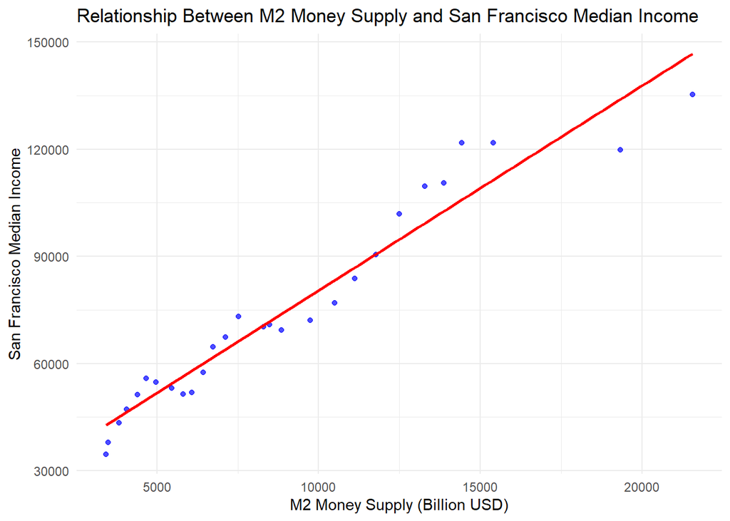

```r
ggplot(sf_data_clean, aes(x = M2SL, y = Median_Income)) +
  geom_point(color = "blue", alpha = 0.7) +
  geom_smooth(method = "lm", color = "red", se = FALSE) +
  labs(
    title = "Relationship Between M2 Money Supply and San Francisco Median Income",
    x = "M2 Money Supply (Billion USD)",
    y = "San Francisco Median Income"
  ) +
  theme_minimal()
```

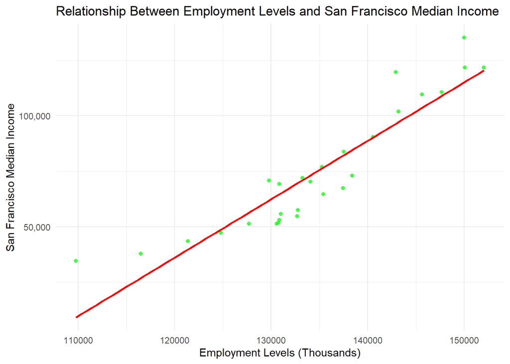

```r
ggplot(sf_data_clean, aes(x = Employment_Thousands, y = Median_Income)) +
  geom_point(color = "green", alpha = 0.7) +
  geom_smooth(method = "lm", color = "red", se = FALSE) +
  labs(
    title = "Relationship Between Employment Levels and San Francisco Median Income",
    x = "Employment Levels (Thousands)",
    y = "San Francisco Median Income"
  ) +
  theme_minimal()+
  scale_y_continuous(labels = scales::comma)
```

### USA DATA ANALYSIS

```r
# Merge and clean the USA-specific data
usa_data <- merged_income_df %>%
  select(DATE, `USA Median Income`) %>%
  rename(Median_Income = `USA Median Income`) %>%
  left_join(
    merged_electricity_df %>% select(DATE, `USA Electricity Cost per Kilowatt-Hour`),
    by = "DATE"
  ) %>%
  left_join(
    cpi_df %>% rename(CPI_Index = `CPI Index`),
    by = "DATE"
  ) %>%
  left_join(
    m2_money_supply_df,
    by = "DATE"
  ) %>%
  left_join(
    employment_df %>% rename(Employment_Thousands = `Population Employed USA Thousand Per Person`),
    by = "DATE"
  )

usa_data_clean <- usa_data %>% na.omit()


regression_model_usa <- lm(
  Median_Income ~ `USA Electricity Cost per Kilowatt-Hour` + CPI_Index + M2SL + Employment_Thousands,
  data = usa_data_clean
)

summary(regression_model_usa)
```

```
##
## Call:
## lm(formula = Median_Income ~ `USA Electricity Cost per Kilowatt-Hour` +
##     CPI_Index + M2SL + Employment_Thousands, data = usa_data_clean)
##
## Residuals:
##      Min       1Q   Median       3Q      Max
## -2036.24  -688.94    -8.26   503.91  2892.63
##
## Coefficients:
##                                            Estimate Std. Error t value Pr(>|t|)
## (Intercept)                              -2.306e+04  4.595e+03  -5.019 2.41e-05
## `USA Electricity Cost per Kilowatt-Hour`  1.341e+04  3.637e+04   0.369    0.715
## CPI_Index                                 2.160e+01  3.835e+01   0.563    0.578
## M2SL                                      1.383e+00  1.257e-01  11.009 7.14e-12
## Employment_Thousands                      4.108e-01  5.924e-02   6.934 1.28e-07
##
## (Intercept)                              ***
## `USA Electricity Cost per Kilowatt-Hour`
## CPI_Index
## M2SL                                     ***
## Employment_Thousands                     ***
## ---
## Signif. codes:  0 '***' 0.001 '**' 0.01 '*' 0.05 '.' 0.1 ' ' 1
##
## Residual standard error: 1054 on 29 degrees of freedom
## Multiple R-squared:  0.9946, Adjusted R-squared:  0.9939
## F-statistic:  1345 on 4 and 29 DF,  p-value: < 2.2e-16
```

# Regression Analysis: USA Median Income

## 1. Overall Model Fit

- **Multiple R-squared (0.9946)**:
  - The model explains 99.46% of the variation in USA Median Income, indicating an exceptionally strong fit.
- **Adjusted R-squared (0.9939)**:
  - After accounting for the number of predictors, the model still explains a substantial portion of the variation in USA Median Income.
- **F-statistic (1345, p < 2.2e-16)**:
  - The overall model is highly significant, meaning at least one predictor has a strong relationship with USA Median Income.

## 2. Coefficients

Each coefficient represents the estimated impact of a one-unit increase in the predictor on USA Median Income, holding other variables constant:

- **Intercept (-23,060)**:
  - When all predictors are zero, the model predicts a baseline USA Median Income of -$23,060.
  - This value is not meaningful as predictors like `M2 Money Supply` and `Employment_Thousands` cannot realistically be zero.
- **USA Electricity Cost per Kilowatt-Hour (13,410)**:
  - **Estimate**: A $1 increase in electricity costs is associated with a $13,410 increase in USA Median Income.
  - **p-value (0.715)**: Not statistically significant (p > 0.05), suggesting that electricity costs do not have a measurable impact on USA Median Income in this model.
- **CPI Index (21.60)**:
  - **Estimate**: A one-unit increase in the CPI Index is associated with a $21.60 increase in USA Median Income.
  - **p-value (0.578)**: Not statistically significant (p > 0.05). CPI does not have a meaningful relationship with USA Median Income in this model.
- **M2 Money Supply (1.383)**:
  - **Estimate**: A $1 billion increase in M2 money supply is associated with a $1.383 increase in USA Median Income.
  - **p-value (7.14e-12)**: Highly statistically significant (p < 0.001). There is a strong positive relationship between M2 money supply and USA Median Income.
- **Employment Levels (0.4108)**:
  - **Estimate**: An increase of 1,000 employed persons in the USA is associated with a $0.4108 increase in USA Median Income.
  - **p-value (1.28e-07)**: Highly statistically significant (p < 0.001). Employment levels are strongly correlated with USA Median Income.

## 3. Residuals

- **Residual Standard Error (1054)**:
  - Indicates the typical difference between observed and predicted values for USA Median Income.
  - Residuals are smaller compared to the city-specific models, suggesting more precise predictions.

## 4. Key Takeaways

### Significant Predictors:

- **M2 Money Supply**:
  - Highly significant and positively correlated with USA Median Income, as in the city-level analyses.
- **Employment Levels**:
  - Also highly significant and positively correlated, highlighting the importance of job availability and labor market trends.

### Insignificant Predictors:

- **USA Electricity Costs**:
  - Not significant, suggesting electricity costs do not directly drive USA Median Income.
- **CPI Index**:
  - As with NYC, Miami, and SF, CPI is not a significant predictor in this model.

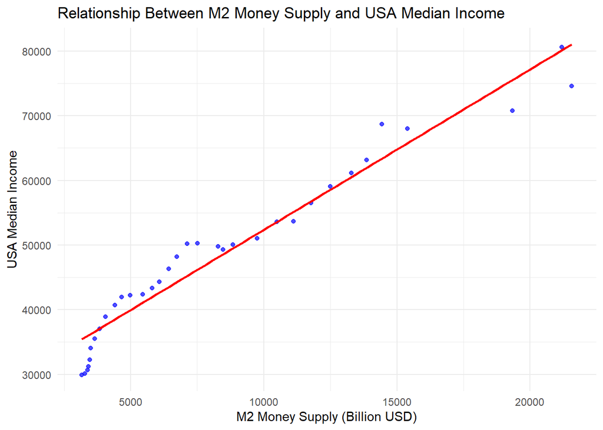

```r
ggplot(usa_data_clean, aes(x = M2SL, y = Median_Income)) +
  geom_point(color = "blue", alpha = 0.7) +
  geom_smooth(method = "lm", color = "red", se = FALSE) +
  labs(
    title = "Relationship Between M2 Money Supply and USA Median Income",
    x = "M2 Money Supply (Billion USD)",
    y = "USA Median Income"
  ) +
  theme_minimal()
```

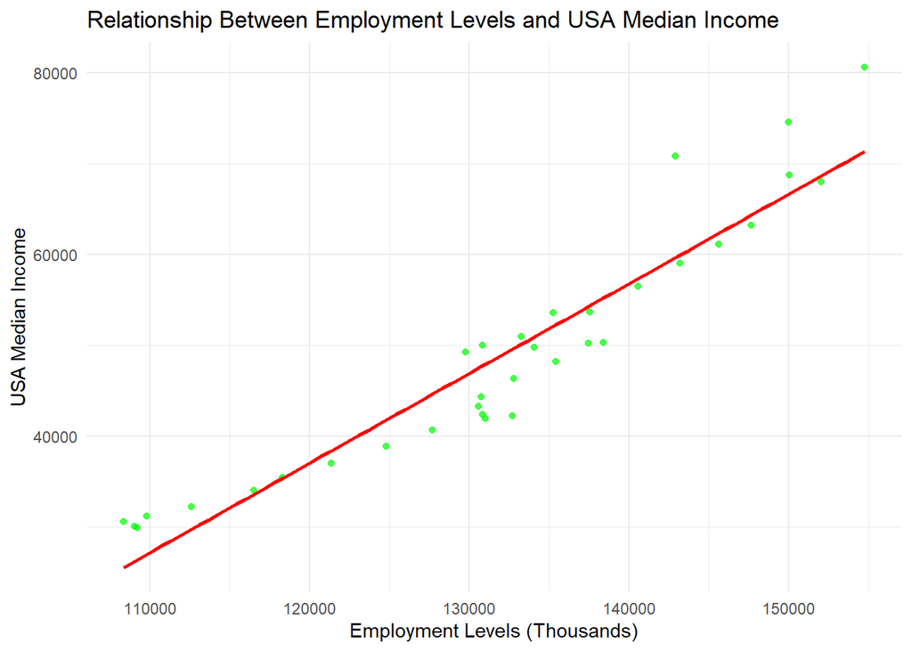

```r
ggplot(usa_data_clean, aes(x = Employment_Thousands, y = Median_Income)) +
  geom_point(color = "green", alpha = 0.7) +
  geom_smooth(method = "lm", color = "red", se = FALSE) +
  labs(
    title = "Relationship Between Employment Levels and USA Median Income",
    x = "Employment Levels (Thousands)",
    y = "USA Median Income"
  ) +
  theme_minimal()
```

### USA DATA ANAYSIS FOR HOUSING

```r
# Merge and clean USA Median Housing Price data
usa_housing_data <- median_house_prices_sold_usa_df %>%
  left_join(
    cpi_df %>% rename(CPI_Index = `CPI Index`),
    by = "DATE"
  ) %>%
  left_join(
    m2_money_supply_df,
    by = "DATE"
  ) %>%
  left_join(
    employment_df %>% rename(Employment_Thousands = `Population Employed USA Thousand Per Person`),
    by = "DATE"
  )

usa_housing_data_clean <- usa_housing_data %>% na.omit()

regression_model_housing <- lm(
  `Median Housing Price Sold USA` ~ CPI_Index + M2SL + Employment_Thousands,
  data = usa_housing_data_clean
)

summary(regression_model_housing)
```

```
##
## Call:
## lm(formula = `Median Housing Price Sold USA` ~ CPI_Index + M2SL +
##     Employment_Thousands, data = usa_housing_data_clean)
##
## Residuals:
##    Min     1Q Median     3Q    Max
## -24206  -9153   -377   5656  33289
##
## Coefficients:
##                        Estimate Std. Error t value Pr(>|t|)
## (Intercept)          -1.605e+05  1.968e+04  -8.157 2.11e-13 ***
## CPI_Index             2.579e+02  1.245e+02   2.071   0.0402 *
## M2SL                  9.835e+00  7.485e-01  13.140  < 2e-16 ***
## Employment_Thousands  1.907e+00  2.515e-01   7.582 4.92e-12 ***
## ---
## Signif. codes:  0 '***' 0.001 '**' 0.01 '*' 0.05 '.' 0.1 ' ' 1
##
## Residual standard error: 12780 on 135 degrees of freedom
## Multiple R-squared:  0.9806, Adjusted R-squared:  0.9801
## F-statistic:  2272 on 3 and 135 DF,  p-value: < 2.2e-16
```

# Regression Analysis: USA Median Housing Prices

## 1. Overall Model Fit

- **Multiple R-squared (0.9806)**:
  - The model explains 98.06% of the variation in USA Median Housing Prices, indicating a very strong fit.
- **Adjusted R-squared (0.9801)**:
  - After accounting for the number of predictors, the model still explains a substantial portion of the variation.
- **F-statistic (2272, p < 2.2e-16)**:
  - The overall model is highly significant, meaning at least one predictor has a strong relationship with USA Median Housing Prices.

## 3. Residuals

- **Residual Standard Error (12,780)**:
  - Indicates the typical difference between observed and predicted values for USA Median Housing Prices.
  - Residuals are relatively small given the large scale of housing prices.

## 4. Key Takeaways

### Significant Predictors:

- **CPI Index**:
  - Statistically significant and positively correlated with housing prices. Inflation drives up housing costs, as expected.
- **M2 Money Supply**:
  - Highly significant and positively correlated. An increase in money supply often leads to greater spending capacity and higher housing prices.
- **Employment Levels**:
  - Highly significant and positively correlated. More employment leads to greater demand for housing, driving up prices.

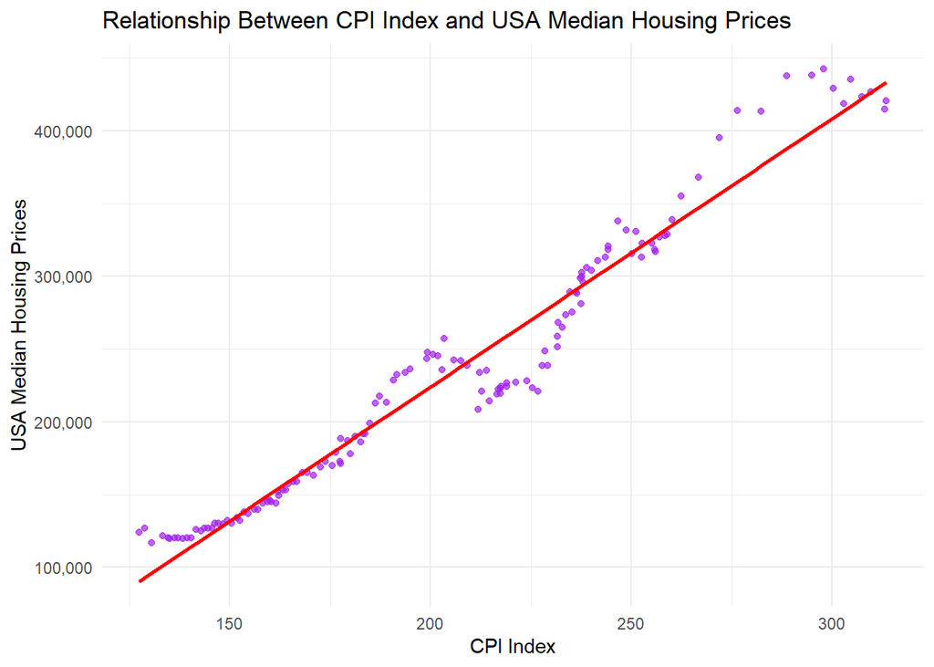

```r
ggplot(usa_housing_data_clean, aes(x = CPI_Index, y = `Median Housing Price Sold USA`)) +
  geom_point(color = "purple", alpha = 0.7) +
  geom_smooth(method = "lm", color = "red", se = FALSE) +
  labs(
    title = "Relationship Between CPI Index and USA Median Housing Prices",
    x = "CPI Index",
    y = "USA Median Housing Prices"
  ) +
  theme_minimal()+
  scale_y_continuous(labels = scales::comma)
```

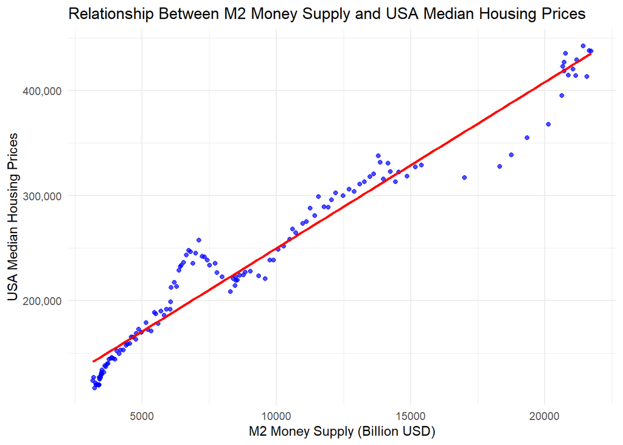

```r
ggplot(usa_housing_data_clean, aes(x = M2SL, y = `Median Housing Price Sold USA`)) +
  geom_point(color = "blue", alpha = 0.7) +
  geom_smooth(method = "lm", color = "red", se = FALSE) +
  labs(
    title = "Relationship Between M2 Money Supply and USA Median Housing Prices",
    x = "M2 Money Supply (Billion USD)",
    y = "USA Median Housing Prices"
  ) +
  theme_minimal()+
  scale_y_continuous(labels = scales::comma)
```

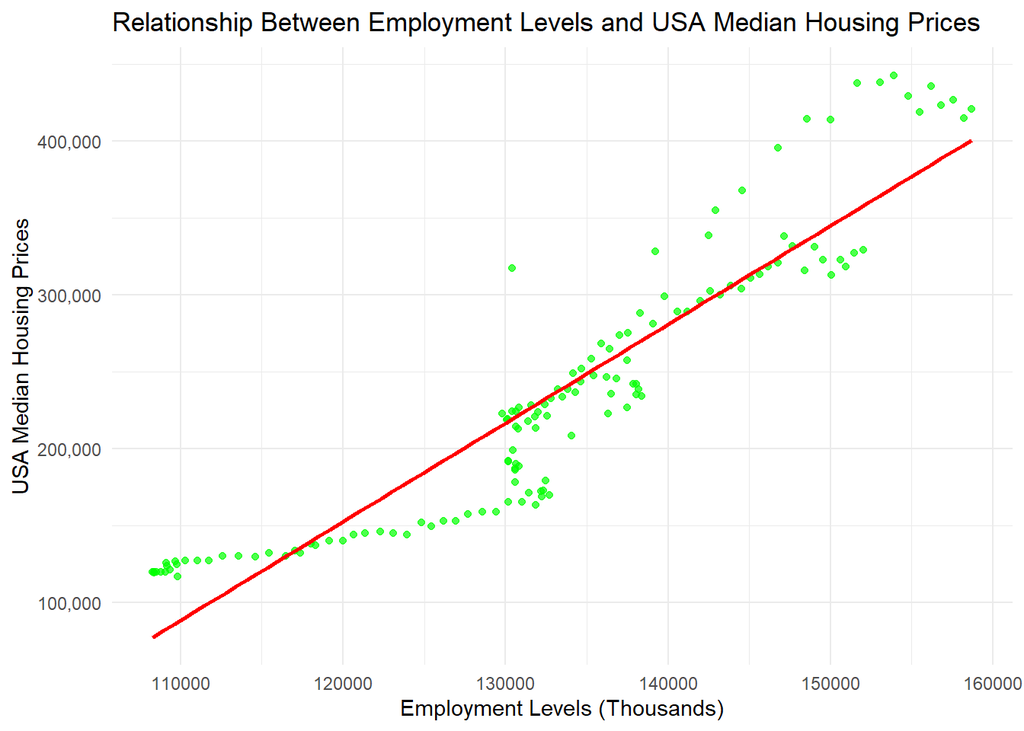

```r
ggplot(usa_housing_data_clean, aes(x = Employment_Thousands, y = `Median Housing Price Sold USA`)) +
  geom_point(color = "green", alpha = 0.7) +
  geom_smooth(method = "lm", color = "red", se = FALSE) +
  labs(
    title = "Relationship Between Employment Levels and USA Median Housing Prices",
    x = "Employment Levels (Thousands)",
    y = "USA Median Housing Prices"
  ) +
  theme_minimal()+
  scale_y_continuous(labels = scales::comma)
```

```r
# load data
rawhousingprices <- "https://raw.githubusercontent.com/crystaliquezada/finalproject_data607/refs/heads/main/data/usa/Media%20Housing%20Price.csv"
housingprices <- read.csv(rawhousingprices)
head(housingprices)
```

```
##   RegionID SizeRank      RegionName RegionType StateName X2018.03.31
## 1   102001        0   United States    country                263267
## 2   394913        1    New York, NY        msa        NY      503000
## 3   753899        2 Los Angeles, CA        msa        CA      721333
## 4   394463        3     Chicago, IL        msa        IL      284600
## 5   394514        4      Dallas, TX        msa        TX      322997
## 6   394692        5     Houston, TX        msa        TX      294467
##   X2018.04.30 X2018.05.31 X2018.06.30 X2018.07.31 X2018.08.31 X2018.09.30
## 1      271267      276633      280000      280300      279633      279600
## 2      513000      521300      526300      528300      526600      526267
## 3      735000      743333      750000      749667      742967      736267
## 4      294600      300600      302267      301967      297933      296117
## 5      328497      331797      332800      329502      324202      321168
## 6      297933      299633      299933      299633      297800      296165
##   X2018.10.31 X2018.11.30 X2018.12.31 X2019.01.31 X2019.02.28 X2019.03.31
```

[output cut: 90 more lines]

Since our focus is on three specific cities, we filter the data to include only New York, Miami, and Los Angeles. We then clean the dataset by renaming the variables and restructuring it from a wide format to a longer format.

```r
filtered_housingprices <- housingprices %>%
  filter(RegionName %in% c("New York, NY", "Miami, FL", "Los Angeles, CA")) %>%
  pivot_longer(
    cols = starts_with("X20"),
    names_to = "Month",
    values_to = "Value"
  ) %>%
  mutate(Month = as.Date(Month, format = "X%Y.%m.%d")) %>%
  mutate(Year = format(Month, "%Y")) %>%
  group_by(Year, RegionName) %>%
  mutate(Yearly_Mean = mean(Value, na.rm = TRUE)) %>%
  select("SizeRank", "RegionName", "Year", "Yearly_Mean") %>%
  distinct()
head(filtered_housingprices)
```

```
## # A tibble: 6 × 4
## # Groups:   Year, RegionName [6]
##   SizeRank RegionName   Year  Yearly_Mean
##      <int> <chr>        <chr>       <dbl>
## 1        1 New York, NY 2018      522903.
## 2        1 New York, NY 2019      540720.
## 3        1 New York, NY 2020      570358.
## 4        1 New York, NY 2021      587392.
## 5        1 New York, NY 2022      603637.
## 6        1 New York, NY 2023      663933.
```

Since 2018, housing prices have risen significantly across all three cities, with the most dramatic increase observed in Los Angeles.

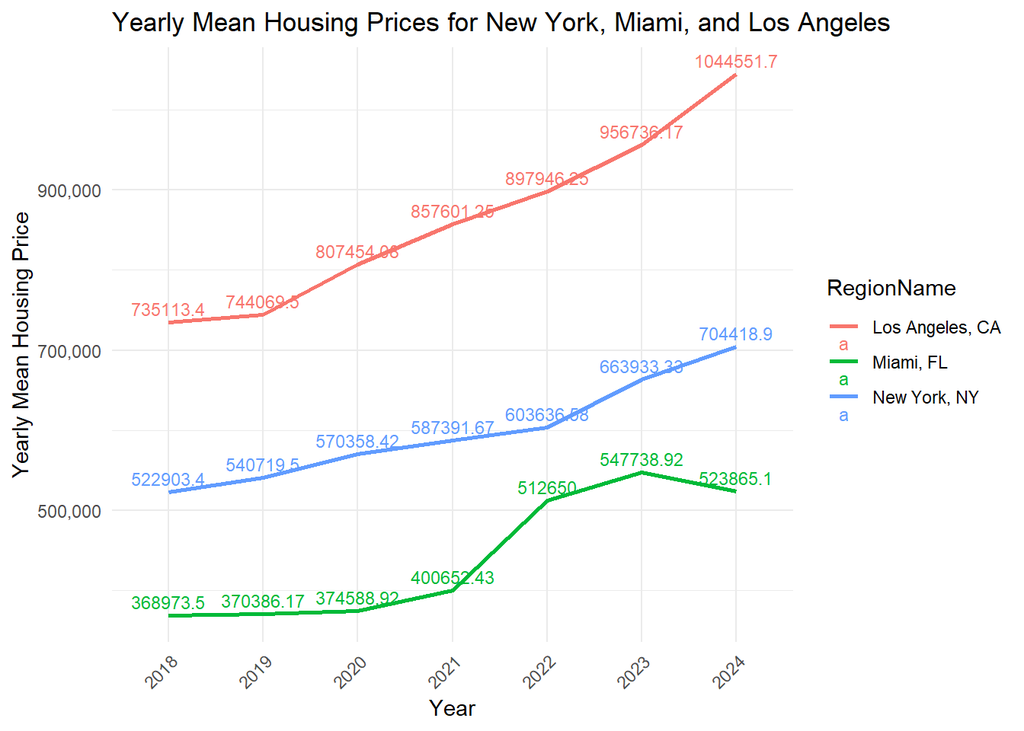

```r
ggplot(filtered_housingprices, aes(x = Year, y = Yearly_Mean, color = RegionName, group = RegionName)) +
  geom_line(size = 1) +
  geom_text(aes(label = round(Yearly_Mean, 2)), vjust = -0.5, size = 3, check_overlap = TRUE) +
  labs(
    title = "Yearly Mean Housing Prices for New York, Miami, and Los Angeles",
    x = "Year",
    y = "Yearly Mean Housing Price"
  ) +
  theme_minimal() +
  theme(axis.text.x = element_text(angle = 45, hjust = 1))+
  scale_y_continuous(labels = scales::comma)
```

The rate of change in housing prices shows that Miami experienced the most significant fluctuation, with a nearly 28% increase. It’s also the only city to see a negative change in 2024, at -4%. On the other hand, both New York and Los Angeles saw more stable price changes, with no year surpassing a 10%.

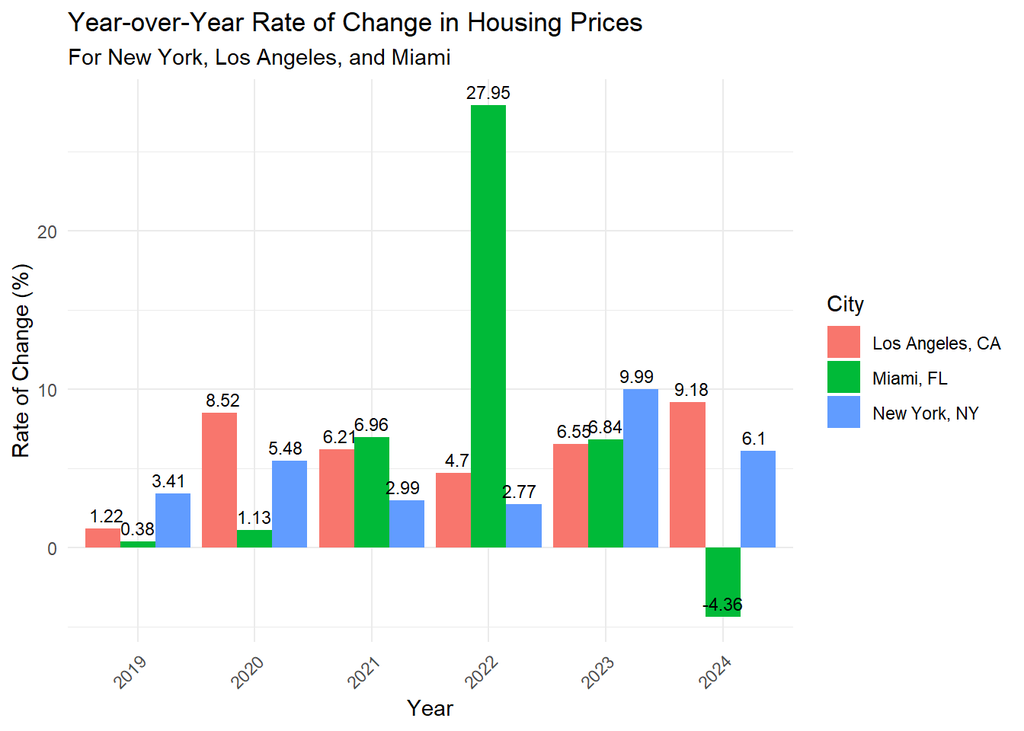

```r
housing_rate_of_change <- filtered_housingprices %>%
  group_by(RegionName) %>%
  arrange(Year) %>%
  mutate(
    Rate_of_Change = (Yearly_Mean - lag(Yearly_Mean)) / lag(Yearly_Mean) * 100
  ) %>%
  filter(!is.na(Rate_of_Change))

ggplot(housing_rate_of_change, aes(x = Year, y = Rate_of_Change, fill = RegionName)) +
  geom_bar(stat = "identity", position = "dodge") +
  geom_text(aes(label = round(Rate_of_Change, 2)),
            position = position_dodge(width = 0.8),
            vjust = -0.5, size = 3) +
  labs(
    title = "Year-over-Year Rate of Change in Housing Prices",
    subtitle = "For New York, Los Angeles, and Miami",
    x = "Year",
    y = "Rate of Change (%)",
    fill = "City"
  ) +
  theme_minimal() +
  theme(axis.text.x = element_text(angle = 45, hjust = 1))
```

```r
anova_housingprices <- aov(Yearly_Mean ~ RegionName, data = filtered_housingprices)
summary(anova_housingprices)
```

```
##             Df    Sum Sq   Mean Sq F value   Pr(>F)
## RegionName   2 6.329e+11 3.165e+11   40.21 2.29e-07 ***
## Residuals   18 1.417e+11 7.870e+09
## ---
## Signif. codes:  0 '***' 0.001 '**' 0.01 '*' 0.05 '.' 0.1 ' ' 1
```

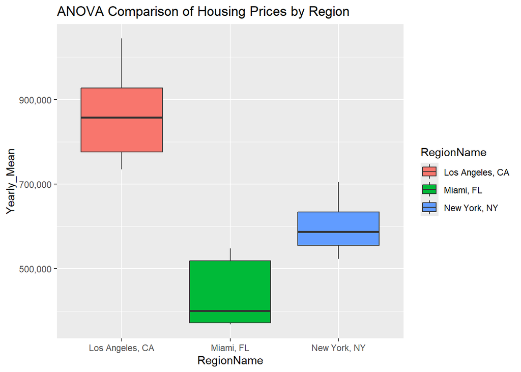

```r
ggplot(filtered_housingprices, aes(x = RegionName, y = Yearly_Mean, fill = RegionName)) +
  geom_boxplot() +
  labs(title = "ANOVA Comparison of Housing Prices by Region")+
  scale_y_continuous(labels = scales::comma)
```

# Median Income

Again, we load the CSV file from GitHub.

```r
rawincome <- read.csv("https://raw.githubusercontent.com/crystaliquezada/finalproject_data607/refs/heads/main/data/usa/Income.csv")
head(rawincome)
```

```
##   Metropolitan.Statistical.Areas X2021.Dollars X2022.Dollars X2023.Dollars
## 1                    Abilene, TX        51,995        53,514        56,034
## 2                      Akron, OH        59,583        59,609        62,904
## 3                     Albany, GA        46,969        46,754        48,546
## 4             Albany-Lebanon, OR        52,230        54,123        57,016
## 5    Albany-Schenectady-Troy, NY        66,929        67,884        71,972
## 6                Albuquerque, NM        52,372        54,687        57,278
##   US.Rank.2023
## 1          239
## 2          130
## 3          344
## 4          219
## 5           57
## 6          216
```

Then, we filter for the appropriate cities while reformatting the column names and structure.

```r
filtered_income <- rawincome %>%
  filter(Metropolitan.Statistical.Areas %in% c("Los Angeles-Long Beach-Anaheim, CA", "Miami-Fort Lauderdale-Pompano Beach, FL", "New York-Newark-Jersey City, NY-NJ-PA") ) %>%
  rename_with(~ gsub("^X", "", .x), starts_with("X")) %>%
  pivot_longer(
    cols = starts_with("20"),
    names_to = "Income by Year",
    values_to = "Average Income"
  ) %>%
  mutate(`Income by Year` = str_remove(`Income by Year`, "\\.Dollars"))
head(filtered_income)
```

```
## # A tibble: 6 × 4
##   Metropolitan.Statistical.Areas  US.Rank.2023 `Income by Year` `Average Income`
##   <chr>                                  <int> <chr>            <chr>
## 1 Los Angeles-Long Beach-Anaheim…           24 2021             75,332
## 2 Los Angeles-Long Beach-Anaheim…           24 2022             76,760
## 3 Los Angeles-Long Beach-Anaheim…           24 2023             80,898
## 4 Miami-Fort Lauderdale-Pompano …           19 2021             73,220
## 5 Miami-Fort Lauderdale-Pompano …           19 2022             78,610
## 6 Miami-Fort Lauderdale-Pompano …           19 2023             84,302
```

In recent years, the average income in the New York area has seen notable growth, making it the highest among the three regions. Miami surpassed Los Angeles’ 2021 income in both 2022 and 2023. Meanwhile, Los Angeles has experienced the slowest growth in comparison.

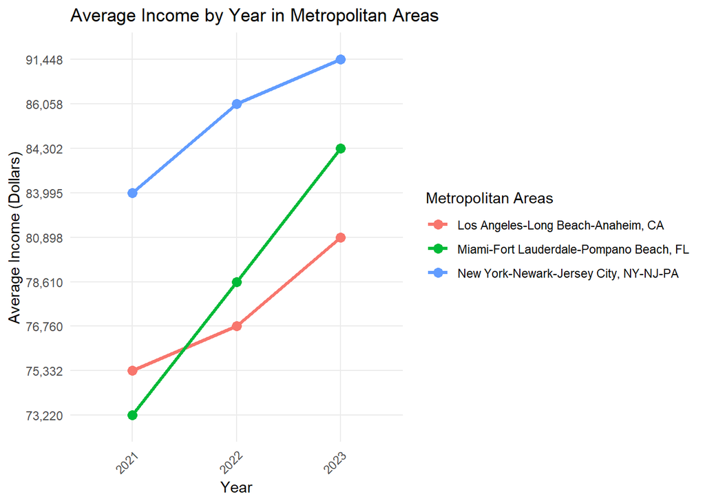

```r
ggplot(filtered_income, aes(x = `Income by Year`, y = `Average Income`,
                            group = Metropolitan.Statistical.Areas,
                            color = Metropolitan.Statistical.Areas)) +
  geom_line(size = 1.2) +
  geom_point(size = 3) +
  labs(
    title = "Average Income by Year in Metropolitan Areas",
    x = "Year",
    y = "Average Income (Dollars)",
    color = "Metropolitan Areas"
  ) +
  theme_minimal() +
  theme(axis.text.x = element_text(angle = 45, hjust = 1))
```

For both 2022 and 2023, Miami had the greatest change of income growth, followed by New York and Los Angeles.

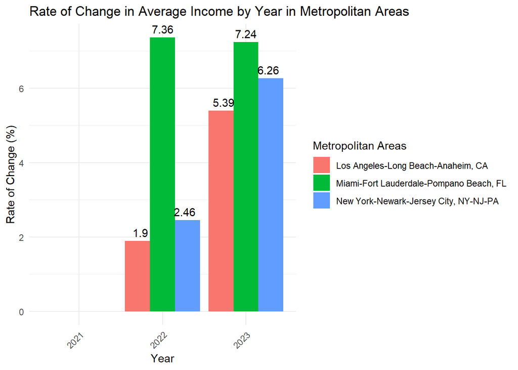

```r
filtered_income_num <- filtered_income %>%
  mutate(`Average Income` = as.numeric(gsub(",", "", gsub("\\$", "", `Average Income`))))

filtered_income_change <- filtered_income_num %>%
  arrange(Metropolitan.Statistical.Areas, `Income by Year`) %>%
  group_by(Metropolitan.Statistical.Areas) %>%
  mutate(rate_of_change = (`Average Income` - lag(`Average Income`)) / lag(`Average Income`) * 100)

ggplot(filtered_income_change, aes(x = `Income by Year`, y = rate_of_change,
                            fill = Metropolitan.Statistical.Areas,
                            label = round(rate_of_change, 2))) +
  geom_bar(stat = "identity", position = "dodge") +
  geom_text(aes(label = round(rate_of_change, 2)), position = position_dodge(width = 0.8), vjust = -0.5) +
  labs(
    title = "Rate of Change in Average Income by Year in Metropolitan Areas",
    x = "Year",
    y = "Rate of Change (%)",
    fill = "Metropolitan Areas"
  ) +
  theme_minimal() +
  theme(axis.text.x = element_text(angle = 45, hjust = 1))
```

A heatmap visual — where the darkest and highest income (above 90k) is found in the NY area as of 2023.

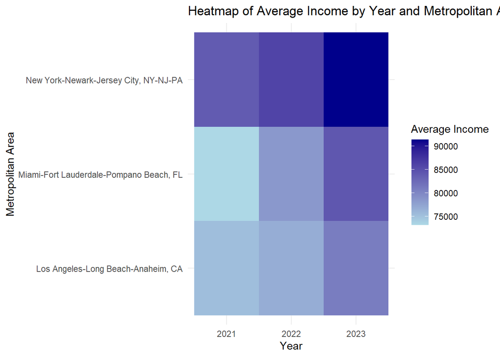

```r
filtered_income$`Average Income` <- as.numeric(gsub(",", "", filtered_income$`Average Income`))

ggplot(filtered_income, aes(x = `Income by Year`, y = Metropolitan.Statistical.Areas, fill = `Average Income`)) +
  geom_tile() +
  scale_fill_gradient(low = "lightblue", high = "darkblue") +
  labs(
    title = "Heatmap of Average Income by Year and Metropolitan Area",
    x = "Year",
    y = "Metropolitan Area",
    fill = "Average Income"
  ) +
  theme_minimal()
```

# Homeownership Rates

For our homeownership rates data, we loaded the csv and removed the first few lines.

```r
rawhomeownership <- read_csv("https://raw.githubusercontent.com/crystaliquezada/finalproject_data607/refs/heads/main/data/usa/Homeownership%20Rates%20-%20Sheet1.csv")
```

```
## ──────────────────────────────────────────────────────── Delimiter: "," chr
## (1): Metropolitan Statistical Area dbl (24): First Quarter 2023, Margin of
## Error1...3, Second Quarter 2023,...
```

```r
rawhomeownership$`Metropolitan Statistical Area` <- gsub("[,\\.]", "", rawhomeownership$`Metropolitan Statistical Area`)
rawhomeownership <- rawhomeownership[-c(1, 2, 3), ]
rawhomeownership
```

```
## # A tibble: 76 × 25
##    `Metropolitan Statistical Area` `First  Quarter  2023` `Margin of Error1...3`
##    <chr>                                            <dbl>                  <dbl>
##  1 "Akron OH "                                       64.5                    9.4
##  2 "Albany-Schenectady-Troy NY "                     79.6                    8.1
##  3 "Albuquerque NM"                                  67.2                    4.5
##  4 "Allentown-Bethlehem-Easton PA…                   69.7                    9.7
##  5 "Atlanta-Sandy Springs-Roswell…                   66.6                    3.6
##  6 "Austin-Round Rock TX"                            63.4                    6
##  7 "Baltimore-Columbia-Towson MD2"                   72.9                    5.2
##  8 "Baton Rouge LA………………………………………"                   64.8                    6.2
##  9 "Birmingham-Hoover AL"                            67                      6.1
## 10 "Boston-Cambridge-Newton MA-NH…                   61.1                    3.5
## # ℹ 66 more rows
## # ℹ 22 more variables: `Second  Quarter  2023` <dbl>,
## #   `Margin of Error1...5` <dbl>, `Third  Quarter  2023` <dbl>,
## #   `Margin of Error1...7` <dbl>, `Fourth  Quarter  2023` <dbl>,
## #   `Margin of Error1...9` <dbl>, `First  Quarter  2022` <dbl>,
## #   `Margin of Error1...11` <dbl>, `Second  Quarter  2022` <dbl>,
## #   `Margin of Error1...13` <dbl>, `Third  Quarter  2022` <dbl>, …
```

To clean our data, we had to restructure the columns and rearrange by Quarter and Year. Otherwise, our x-axis would present in alphabetical order, and therefore not in time order.

```r
rawhomeownership <- rawhomeownership %>%
  clean_names()
rawhomeownership
```

```
## # A tibble: 76 × 25
##    metropolitan_statistical_area       first_quarter_2023 margin_of_error1_3
##    <chr>                                            <dbl>              <dbl>
##  1 "Akron OH "                                       64.5                9.4
##  2 "Albany-Schenectady-Troy NY "                     79.6                8.1
##  3 "Albuquerque NM"                                  67.2                4.5
##  4 "Allentown-Bethlehem-Easton PA-NJ"                69.7                9.7
##  5 "Atlanta-Sandy Springs-Roswell GA1"               66.6                3.6
##  6 "Austin-Round Rock TX"                            63.4                6
##  7 "Baltimore-Columbia-Towson MD2"                   72.9                5.2
##  8 "Baton Rouge LA………………………………………"                   64.8                6.2
##  9 "Birmingham-Hoover AL"                            67                  6.1
## 10 "Boston-Cambridge-Newton MA-NH3"                  61.1                3.5
## # ℹ 66 more rows
## # ℹ 22 more variables: second_quarter_2023 <dbl>, margin_of_error1_5 <dbl>,
## #   third_quarter_2023 <dbl>, margin_of_error1_7 <dbl>,
## #   fourth_quarter_2023 <dbl>, margin_of_error1_9 <dbl>,
## #   first_quarter_2022 <dbl>, margin_of_error1_11 <dbl>,
## #   second_quarter_2022 <dbl>, margin_of_error1_13 <dbl>,
## #   third_quarter_2022 <dbl>, margin_of_error1_15 <dbl>, …
```

```r
homeownership <- rawhomeownership %>%
  filter(`metropolitan_statistical_area` %in% c("Los Angeles-Long Beach-Anaheim CA14",
                                                "Miami-Fort Lauderdale-West Palm Beach FL16",
                                                "New York-Newark-Jersey City NY-NJ-PA19")) %>%
  select(`metropolitan_statistical_area`, `first_quarter_2021`, `second_quarter_2021`, `third_quarter_2021`, `fourth_quarter_2021`,
         `first_quarter_2022`, `second_quarter_2022`, `third_quarter_2022`, `fourth_quarter_2022`,
         `first_quarter_2023`, `second_quarter_2023`, `third_quarter_2023`, `fourth_quarter_2023`) %>%
   pivot_longer(
    cols = -`metropolitan_statistical_area`,
    names_to = "year_quarter",
    values_to = "homeownership_rate"
  ) %>%
  mutate(
    quarter = case_when(
      grepl("first", year_quarter) ~ "Q1",
      grepl("second", year_quarter) ~ "Q2",
      grepl("third", year_quarter) ~ "Q3",
      grepl("fourth", year_quarter) ~ "Q4"
    ),
    year = sub(".*(\\d{4}).*", "\\1", year_quarter),
    label = paste(quarter, year),
    label = factor(label, levels = c("Q1 2021", "Q2 2021", "Q3 2021", "Q4 2021",
                                     "Q1 2022", "Q2 2022", "Q3 2022", "Q4 2022",
                                     "Q1 2023", "Q2 2023", "Q3 2023", "Q4 2023"))
  )
homeownership
```

```
## # A tibble: 36 × 6
##    metropolitan_statistica…¹ year_quarter homeownership_rate quarter year  label
##    <chr>                     <chr>                     <dbl> <chr>   <chr> <fct>
##  1 Los Angeles-Long Beach-A… first_quart…               61.2 Q1      2021  Q1 2…
##  2 Los Angeles-Long Beach-A… second_quar…               65.7 Q2      2021  Q2 2…
##  3 Los Angeles-Long Beach-A… third_quart…               63.9 Q3      2021  Q3 2…
##  4 Los Angeles-Long Beach-A… fourth_quar…               67.7 Q4      2021  Q4 2…
##  5 Los Angeles-Long Beach-A… first_quart…               63.4 Q1      2022  Q1 2…
##  6 Los Angeles-Long Beach-A… second_quar…               64   Q2      2022  Q2 2…
##  7 Los Angeles-Long Beach-A… third_quart…               62.4 Q3      2022  Q3 2…
##  8 Los Angeles-Long Beach-A… fourth_quar…               67.8 Q4      2022  Q4 2…
##  9 Los Angeles-Long Beach-A… first_quart…               46.1 Q1      2023  Q1 2…
## 10 Los Angeles-Long Beach-A… second_quar…               46.8 Q2      2023  Q2 2…
## # ℹ 26 more rows
## # ℹ abbreviated name: ¹metropolitan_statistical_area
```

All areas show a downward trend in homeownership despite an upward trend in average income.

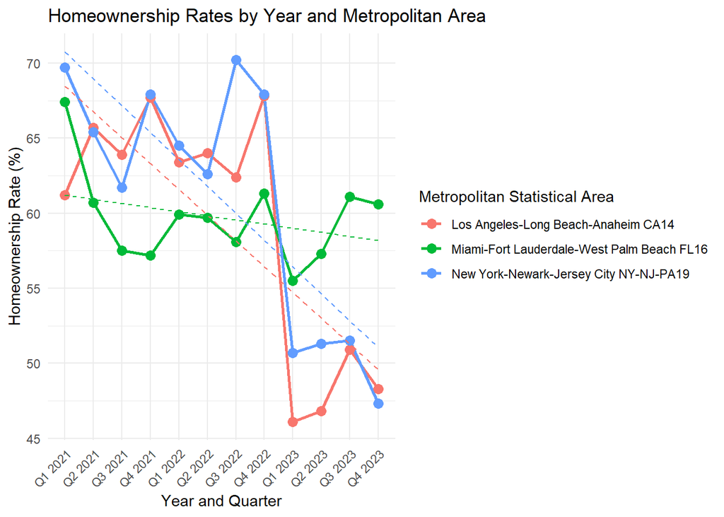

```r
ggplot(homeownership, aes(x = label, y = `homeownership_rate`, color = `metropolitan_statistical_area`, group = `metropolitan_statistical_area`)) +
  geom_line(size = 1) +
  geom_point(size = 3) +
  geom_smooth(method = "lm", se = FALSE, linetype = "dashed", size = 0.5) +  # Separate linear models for each region
  labs(
    title = "Homeownership Rates by Year and Metropolitan Area",
    x = "Year and Quarter",
    y = "Homeownership Rate (%)",
    color = "Metropolitan Statistical Area"
  ) +
  theme_minimal() +
  theme(axis.text.x = element_text(angle = 45, hjust = 1))
```

In fact, Los Angeles had the greatest drop in homeownership rates as of Q1 of 2023 at -32%. If we recall, Los Angeles had the most expensive housing prices, and the slowest average income growth. New York follows at -25%, despite have the highest average income of the areas.

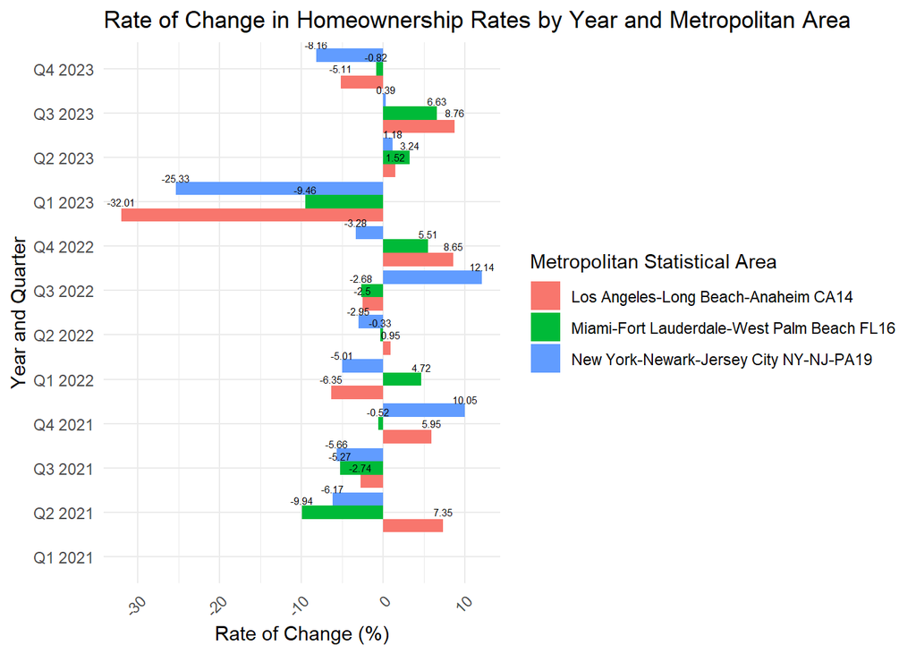

```r
homeownership_change <- homeownership %>%
  group_by(`metropolitan_statistical_area`) %>%
  arrange(`metropolitan_statistical_area`, `label`) %>%
  mutate(rate_of_change = (`homeownership_rate` - lag(`homeownership_rate`)) / lag(`homeownership_rate`) * 100)

ggplot(homeownership_change, aes(x = label, y = rate_of_change, fill = `metropolitan_statistical_area`)) +
  geom_bar(stat = "identity", position = "dodge") +
  geom_text(aes(label = round(rate_of_change, 2)),
            position = position_dodge(width = 0.8),
            vjust = -1, size = 2) +
  labs(
    title = "Rate of Change in Homeownership Rates by Year and Metropolitan Area",
    x = "Year and Quarter",
    y = "Rate of Change (%)",
    fill = "Metropolitan Statistical Area"
  ) +
  theme_minimal() +
  theme(axis.text.x = element_text(angle = 45, hjust = 1)) +
  coord_flip()
```

Here we load the data for non farmer jobs in the US since the 1990s.

```r
raw_nonfarmer <- "https://raw.githubusercontent.com/crystaliquezada/finalproject_data607/refs/heads/main/data/usa/total_non_farm_employment.csv"
nonfarmerjobs <- read_csv(raw_nonfarmer)
nonfarmerjobs
```

```
## # A tibble: 419 × 2
##    DATE       PAYEMS
##    <date>      <dbl>
##  1 1990-01-01 109189
##  2 1990-02-01 109432
##  3 1990-03-01 109637
##  4 1990-04-01 109671
##  5 1990-05-01 109834
##  6 1990-06-01 109857
##  7 1990-07-01 109822
##  8 1990-08-01 109610
##  9 1990-09-01 109520
## 10 1990-10-01 109374
## # ℹ 409 more rows
```

The number of non-farm jobs has steadily increased since 1990, with a significant drop in 2020 due to the pandemic. However, the job market has since rebounded, surpassing pre-pandemic levels. Non-farm jobs make up nearly 80% of the workforce contributing to the country’s GDP. Despite this substantial contribution, homeownership rates have been declining, raising questions about the broader economic and social implications.

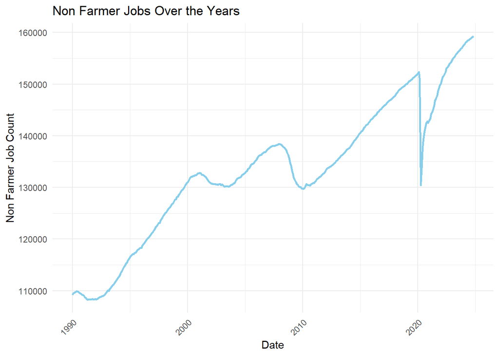

```r
ggplot(nonfarmerjobs, aes(x = DATE, y = PAYEMS)) +
  geom_line(color = "skyblue", size = 1) +
  labs(
    title = "Non Farmer Jobs Over the Years",
    x = "Date",
    y = "Non Farmer Job Count"
  ) +
  theme_minimal() +
  theme(axis.text.x = element_text(angle = 45, hjust = 1))
```

# Conclusion

It’s important for policymakers and stakeholders in California to focus on initiatives that address the affordability crisis and improve access to homeownership. Potential solutions could include expanding affordable housing projects, offering homebuyer assistance programs, and addressing the root causes of income inequality. For New York, focusing on supporting sustainable growth in both income and homeownership could help mitigate the risks of economic disparity. Miami, while showing promising trends, could further benefit from targeted policies that ensure the continued growth of both its housing market and income levels.